# FNDSS_Gaurika_Tyagi

Gaurika Tyagi

1 May 2016

Analyze and visualize data in the FNDDS 2011-2012 Foods database.This project first clubs data from various tables and categorizes them into the desired nutrients. An extra column for cfood category is then added to get the final data. This data frame is used to remove unwanted nutrients and then exploratory analysis is performed on the data. SQL is used to subset the dataset and anlyze it at various stages. GGplots are generated to visualize the various features which help us understand the necesary nutrients to be used to fit SVM and Logistic Regression Models.

```r
#install.packages("tidyr")

setwd("C:/Users/Dr. Tyagi/Documents/MSHI/HS616- R with stats/Week13/dataAnalViz")

data_dir <- "FNDDS_2011"

fortification <- c(`0`="none", `1`="fortified_product", `2`="contains fortified ingredients")

fndds_tables <- list(
    AddFoodDesc = list(
            title="Additional Food Descriptions",
            column_types=c(
                food_code="integer", # foreign key
                seq_num="integer",
                start_date="date",
                end_date="date",
                additional_food_description="text"),
            sep="^"
        ),
    FNDDSNutVal = list(
            title="FNDDS Nutrient Values",
            column_types=c(
                food_code="integer",
                nutrient_code="integer",    # Nutrient Descriptions table
                start_date="date",
                end_date="date",
                nutrient_value="double"
                ),
            sep="^"
        ),
    FNDDSSRLinks = list(
            title="FNDDS-SR Links", # see p34 of fndds_2011_2012_doc.pdf
            column_types=c(
                food_code="integer",
                start_date="date",
                end_date="date",
                seq_num="integer",
                sr_code="integer",
                sr_descripton="text",
                amount="double",
                measure="char[3]",  # lb, oz, g, mg, cup, Tsp, qt, fluid ounce, etc
                portion_code="integer",
                retention_code="integer",
                flag="integer",
                weight="double",
                change_type_to_sr_code="char[1]",   # D=data change; F=food change
                change_type_to_weight="char[1]",
                change_type_to_retn_code="char[1]"
                ),
            sep="^"
        ),
    FoodPortionDesc = list(
            title="Food Portion Descriptions",
            column_types=c(
                portion_code="integer",     # foreign key
                start_date="date",
                end_date="date",
                portion_description="text",
                change_type="char[1]"
            ),
            sep="^"
        ),
    FoodSubcodeLinks = list(
            title="Food code-subcode links",
            column_types=c(
                food_code="integer",
                subcode="integer",
                start_date="date",
                end_date="date"
                ),
            sep="^"
        ),
    FoodWeights = list(
            title="Food Weights",
            column_types=c(
                food_code="integer",    # foreign key
                subcode="integer",
                seq_num="integer",
                portion_code="integer", # food portion description id
                start_date="date",
                end_date="date",
                portion_weight="double",    # missing values = -9
                change_type="char[1]"   # D=data change, F=food change
                ),
            sep="^"
        ),
    MainFoodDesc = list(
            title="Main Food Descriptions",
            column_types=c(
                food_code="integer",
                start_date="date",
                end_date="date",
                main_food_description="character",
                fortification_id="integer"),
            sep="^"
        ),
    ModDesc = list(
            title="Modifications Descriptons",
            column_types=c(
                modification_code="integer",
                start_date="date",
                end_date="date",
                modification_description="text",
                food_code="integer"

                ),
            sep="^"
        ),
    ModNutVal = list(
            title="Modifications Nutrient Values",
            column_types=c(
                modification_code="integer",
                nutrient_code="integer",
                start_date="date",
                end_date="date",
                nutrient_value="double"
                ),
            sep="^"
        ),
    MoistNFatAdjust = list(
            title="Moisture & Fat Adjustments", # to account for changes during cooking
            column_types=c(
                food_code="integer",
                start_date="date",
                end_date="date",
                moisture_change="double",
                fat_change="double",
                type_of_fat="integer"   # SR code or food code
                ),
            sep="^"
        ),
    NutDesc = list(
            title="Nutrient Descriptions",
            column_types=c(
                nutrient_code="integer",
                nutrient_description="text",
                tagname="text",
                unit="text",
                decimals="integer"  # decimal places
                ),
            sep="^"
        ),
    SubcodeDesc = list(
            title="Subcode Descriptions",
            column_types=c(
                subcode="integer",  # key; 0=use default gram weights
                start_date="date",
                end_date="date",
                subcode_description="text"
                ),
            sep="^"
        )
)

# flat file to a data frame: called by fndds2sqlite for each table
assign_data_frame <- function(tbl_name){
    tbl <- read.table(
        file.path(data_dir, paste0(tbl_name, ".txt")),
        sep="^",
        quote="~",
        stringsAsFactors=FALSE)
    # drop last (empty) column
    tbl <- tbl[1:(length(tbl)-1)]
    # gets names of columns from tbl_name element of fndds_tables list of list
    names(tbl) <- names(fndds_tables[[tbl_name]][["column_types"]])
    # assigns the data frame tbl to global variable named by string contents of tbl_name
    assign(tbl_name, tbl, envir = .GlobalEnv)
}

# flat file to database
fndds2sqlite <- function(data_dir, table_details, sqlite_filename){

    library("RSQLite")
  #open database named by sqlite_filename, create empty if doesn't exist
    con <- dbConnect(SQLite(), sqlite_filename)

    for (tbl_name in names(table_details)){
        file_name <- paste0(tbl_name, ".txt") # paste0 has empty string as separator
        assign_data_frame(tbl_name)
        print(file_name)
        tbl <- get(tbl_name)
        print(tbl_name)
        # function exits with error message next line if database already exists
        dbWriteTable(con, tbl_name, tbl, row.names = FALSE)
    }

    dbDisconnect(con)# seems to auto save the updated database
}

#First time run creates the database from flat files and saves to database file
# first run also creates dataframes for each table
#If you run whwn database already exists you get:
# Error: Table AddFoodDesc exists in database, and both overwrite and append are FALSE
# and you get only one data frame, but can go on, no harm done

fndds2sqlite("FNDDS_2011", fndds_tables, "fndds.sqlite")
```

```
## [1] "AddFoodDesc.txt"
## [1] "AddFoodDesc"
## [1] "FNDDSNutVal.txt"
## [1] "FNDDSNutVal"
## [1] "FNDDSSRLinks.txt"
## [1] "FNDDSSRLinks"
## [1] "FoodPortionDesc.txt"
## [1] "FoodPortionDesc"
## [1] "FoodSubcodeLinks.txt"
## [1] "FoodSubcodeLinks"
## [1] "FoodWeights.txt"
## [1] "FoodWeights"
## [1] "MainFoodDesc.txt"
## [1] "MainFoodDesc"
## [1] "ModDesc.txt"
## [1] "ModDesc"
## [1] "ModNutVal.txt"
## [1] "ModNutVal"
## [1] "MoistNFatAdjust.txt"
## [1] "MoistNFatAdjust"
## [1] "NutDesc.txt"
## [1] "NutDesc"
## [1] "SubcodeDesc.txt"
## [1] "SubcodeDesc"
```

```
## [1] TRUE
```

```r
library(DBI)
# Creates 3 of the data frames (useful if database already exists so data frames not created)
for (tbl in c("FNDDSNutVal", "MainFoodDesc", "NutDesc"))
    assign_data_frame(tbl)

library(dplyr)
library(tidyr)

# Make a simplified selection of foods, store in data frame.
# TO DO: have MainFoodDesc be a tbl sourced from SQLite.
get_selected_foods <- function(){
    # Pull out all "Not Further Specified" foods as a wide selection of reasonably generic items.
  # NB: grepl returns boolean for each string in vector: TRUE if a string contains the pattern, otherwise FALSE
    generics <- MainFoodDesc %>%
        filter( grepl(", NFS", main_food_description )) %>%
        filter(!grepl("infant formula", main_food_description, ignore.case = TRUE ) )

    # Raw fruits
    # Berries are covered by "Berries, raw, NFS" and "Berries, frozen, NFS"
    # NB: grepl can search for pattern specified by regular expressions: http://www.rexegg.com/regex-quickstart.html
    # NB: with regular expressions '^' matches empty string at beginning of line
    #  food codes for fruits begin with 6
    fruits <- MainFoodDesc %>%
        filter( grepl("^6", food_code) ) %>%
        filter( grepl("^([^,\\(]+), raw$", main_food_description) ) %>%
        filter( !grepl("berries", main_food_description) )

    # Raw vegetables
    # Potatoes are covered by "White potato, NFS", "Sweet potato, NFS", etc.
    # NB: food codes for vegetables begin with 7
    vegetables <- MainFoodDesc %>%
        filter( grepl("^7", food_code) ) %>%
        filter(!grepl("potato", main_food_description)) %>%
        filter( grepl(", raw$", main_food_description))

    # 4="legumes, nuts, and seeds"
    # NB: food codes for legumes, nuts, and seeds begin with 4
    nuts_and_seeds <- MainFoodDesc %>%
        filter( grepl("^4", food_code) ) %>%
        mutate( firstWord = strsplit(main_food_description, " ")[[1]][1] )

    # Selected alcoholic beverages
    # All alcoholic beverages: grepl("^93", food_code))
    # "Cocktail, NFS" already gives us "Cocktail"
    # NB: food codes for alcoholic beverages begin with 93
    alcoholic_beverages <- MainFoodDesc %>%
        filter( main_food_description %in% c("Beer", "Wine, table, red", "Wine, table, white",
            "Whiskey", "Gin", "Rum", "Vodka") )

    # Collect them all into one table
    rbind(generics, fruits, vegetables, alcoholic_beverages) %>%
        select( food_code, main_food_description, fortification_id )  %>%
        filter( nchar(main_food_description) < 20 ) %>%
      # gsub(pattern, replacement, string_for_Pattern_matching)
      # replace pattern with empty string (remove pattern)
        mutate( main_food_description = gsub("(, NFS|, raw)", "", main_food_description) )

}

foods <- get_selected_foods()   # 163 items
#Original description table
library(sqldf)
long_food_nutrients <- sqldf("SELECT f.main_food_description, nd.nutrient_description, nv.nutrient_value
    FROM foods f
    INNER JOIN FNDDSNutVal nv ON f.food_code = nv.food_code
    INNER JOIN NutDesc nd ON nv.nutrient_code = nd.nutrient_code")
# tidyr spread: Spread a key-value pair across multiple columns.
# spread(data, key, value, fill = NA, convert = FALSE, drop = TRUE)
# data is a data frame.
# key is name of the column whose values will be used as column headings.
# value is name of the column whose values will populate the cells.
# fill If set, missing values will be replaced with this value.
# http://www.rdocumentation.org/packages/tidyr/functions/spread
nutrient_food_df <- spread(long_food_nutrients, main_food_description, nutrient_value, fill=0)

#remove 1st column, convert to matrix, transpose
food_nutrient_mat <- t(as.matrix(nutrient_food_df[-1]))
colnames(food_nutrient_mat) <- nutrient_food_df$nutrient_description

save(food_nutrient_mat, file="food_nutrient_mat.Rdata")
# saveRDS is like save, but with saveRDS, the saved object can be loaded into a named object
#   within R that is different from the name it had when originally serialized.
saveRDS(foods, file="foods.rds")

#*****************************************************************************#
```

We will baically use 3 tables from the main database: 1. “FNDDSNutVal” 2. “MainFoodDesc” 3. “NutDesc”

Using these tables we will perfrom joins and put conditions to obtain the required columns for analysis.

We also modify the above code to obtain the food_code i our data frame. Food code will be used to categorize various foods in different categories.

```r
long_foodcode_nutrients <- sqldf("SELECT f.food_code, nd.nutrient_description, nv.nutrient_value
                             FROM foods f
                             INNER JOIN FNDDSNutVal nv ON f.food_code = nv.food_code
                             INNER JOIN NutDesc nd ON nv.nutrient_code = nd.nutrient_code")

# tidyr spread: Spread a key-value pair across multiple columns.
# spread(data, key, value, fill = NA, convert = FALSE, drop = TRUE)
# data is a data frame.
# key is name of the column whose values will be used as column headings.
# value is name of the column whose values will populate the cells.
# fill If set, missing values will be replaced with this value.
# http://www.rdocumentation.org/packages/tidyr/functions/spread
nutrient_foodcode_df <- spread(long_foodcode_nutrients, food_code, nutrient_value, fill=0)

#remove 1st column, convert to matrix, transpose
foodcode_nutrient_mat <- t(as.matrix(nutrient_foodcode_df[-1]))
colnames(foodcode_nutrient_mat) <- nutrient_foodcode_df$nutrient_description
save(foodcode_nutrient_mat, file="foodcode_nutrient_mat.Rdata")
```

Now that we have the required matrix called **foodcode_nutrient_mat**, we will transform it to a dataframe and add a column called category to store the 11 categories of foods based on the food codes available in the documentation at: http://www.ars.usda.gov/SP2UserFiles/Place/80400530/pdf/fndds/fndds_2011_2012_doc.pdf

```r
fcode_nut_catg<- as.data.frame(foodcode_nutrient_mat, row.names = nutrient_foodcode_df[1])
fcode_nut_catg$food_code <- rownames(foodcode_nutrient_mat)
fcode_nut_catg$food_code <- as.numeric(fcode_nut_catg$food_code)
fcode_nut_catg$category <- ifelse(fcode_nut_catg$food_code>= 10000000 & fcode_nut_catg$food_code<= 19999999, "dairy",
                       ifelse(fcode_nut_catg$food_code>= 20000000 & fcode_nut_catg$food_code<= 29999999,"meat,fish",
                        ifelse(fcode_nut_catg$food_code>= 30000000 & fcode_nut_catg$food_code<= 39999999,"eggs",
                         ifelse(fcode_nut_catg$food_code>= 40000000 & fcode_nut_catg$food_code<= 49999999,"legumes,nuts,seeds",
                          ifelse(fcode_nut_catg$food_code>= 50000000 & fcode_nut_catg$food_code<= 59999999, "grains",
                           ifelse(fcode_nut_catg$food_code>= 60000000 & fcode_nut_catg$food_code<= 69999999, "fruits",
                            ifelse(fcode_nut_catg$food_code>= 70000000 & fcode_nut_catg$food_code<= 79999999, "vegetables",
                             ifelse(fcode_nut_catg$food_code>= 80000000 & fcode_nut_catg$food_code<= 89999999, "fats",
                              ifelse(fcode_nut_catg$food_code>= 90000000 & fcode_nut_catg$food_code<= 92999999, "sugars",
                               ifelse(fcode_nut_catg$food_code>= 93000000 & fcode_nut_catg$food_code<= 93999999, "alcohol",
                                ifelse(fcode_nut_catg$food_code>= 94000000 & fcode_nut_catg$food_code<= 99999999, "protein powder",
                                       NA)))))))))))
```

Let us find the number of times water content in food products when water content is more than the median water content in foods. Finding the top 2 categories of food

```r
variation<- sqldf("SELECT category, SUM(CASE when Water>(SELECT median(Water) FROM fcode_nut_catg) then 1 else 0 end) water
            FROM fcode_nut_catg
            GROUP BY category
            ORDER BY water DESC
            LIMIT 2")
print(variation)
```

```
##     category water
## 1 vegetables    44
## 2     fruits    26
```

It can bee seen that vegetables followed by fruits give the most water content in everydy life.

Let us find the number of times cholesterol content in food products when cholesterol content is more than the median cholesterol content in foods. Finding the top 2 categories of food

```r
variation<- sqldf("SELECT category, SUM(CASE when Cholesterol>(SELECT median(Cholesterol) FROM fcode_nut_catg) then 1 else 0 end) cholesterol
            FROM fcode_nut_catg
            GROUP BY category
            ORDER BY cholesterol DESC
            LIMIT 2")
print(variation)
```

```
##    category cholesterol
## 1 meat,fish          16
## 2    grains           6
```

It can be seen that meat,fish followed by grains supply more than the median level of cholestrol in any foods

Let us find the number of times Iron content in food products when Iron content is more than the median Iron content in foods. Finding the top 2 categories of food

```r
variation<- sqldf("SELECT category, SUM(CASE when Iron>(SELECT median(Iron) FROM fcode_nut_catg) then 1 else 0 end) iron
            FROM fcode_nut_catg
            GROUP BY category
            ORDER BY iron DESC
            LIMIT 2")
print(variation)
```

```
##     category iron
## 1 vegetables   27
## 2     grains   25
```

It can be seen that vegetables, closely followed by grains supply more than the median level of Iron in any foods

Further, the dataset modified before the above analysis has a lot of unwanted nutrients which do not have a clear identification. As can be seen below:

```r
print(head(fcode_nut_catg))
```

```
##    10:0  12:0  14:0  16:0  16:1  18:0  18:1  18:2  18:3  18:4  20:1  20:4
## 1 0.046 0.049 0.173 0.513 0.013 0.225 0.483 0.065 0.027 0.000 0.001 0.000
## 2 0.280 0.310 1.130 3.060 0.206 1.316 2.763 0.275 0.175 0.000 0.000 0.000
## 3 0.000 0.000 0.006 0.580 0.004 0.646 2.718 0.103 0.002 0.000 0.009 0.000
## 4 0.509 0.488 2.548 7.409 0.674 3.000 6.141 0.561 0.231 0.002 0.051 0.008
## 5 0.010 0.010 0.258 2.092 0.327 1.131 3.520 0.248 0.030 0.000 0.000 0.040
## 6 0.000 0.012 0.470 3.537 0.596 1.977 6.297 0.377 0.056 0.000 0.053 0.047
##   20:5 n-3 22:1 22:5 n-3 22:6 n-3   4:0   6:0   8:0 Alcohol Caffeine
## 1    0.000    0    0.000    0.000 0.057 0.041 0.033       0        0
## 2    0.003    0    0.000    0.000 0.360 0.210 0.120       0        0
## 3    0.000    0    0.000    0.000 0.001 0.000 0.000       0        2
## 4    0.003    0    0.004    0.001 0.738 0.377 0.229       0        0
## 5    0.003    0    0.015    0.001 0.000 0.000 0.000       0        0
## 6    0.003    0    0.016    0.001 0.000 0.000 0.000       0        0
##   Calcium Carbohydrate Carotene, alpha Carotene, beta Cholesterol
```

[output cut: 69 more lines]

We want to get rid of these nutrient and lighten our data frame.

```r
#removing first 19 unlabeled nutrients
fcode_nut_catg <- fcode_nut_catg[-c(1:19)]
```

fcode_nut_catg is now a comparitively cleaner version of our earlier table. Here are the first few rows of the data frame to give a little understanding:

```r
print(head(fcode_nut_catg))
```

```
##   Alcohol Caffeine Calcium Carbohydrate Carotene, alpha Carotene, beta
## 1       0        0     119         4.85               0              4
## 2       0        0     128        23.60               0             19
## 3       0        2      51        23.01               0              0
## 4       0        0     950         3.82               0             97
## 5       0        0       8         0.00               0              0
## 6       0        0      23         0.00               0              0
##   Cholesterol Choline, total Copper Cryptoxanthin, beta Energy
## 1           7           15.8  0.014                   0     50
## 2          44           26.0  0.023                   0    207
## 3           1            9.5  0.092                   0    142
## 4          87           22.0  0.032                   9    338
## 5          85          112.9  0.123                   0    209
## 6          88           80.5  0.081                   0    258
##   Fatty acids, total monounsaturated Fatty acids, total polyunsaturated
```

[output cut: 55 more lines]

## Part-1 of Exploratory Analysis

In such a great spread of nutrient values, any value below 1 will be considered too small and is being removed ONLY for initial, broad understanding of the data

```r
res1 <- sqldf("SELECT mfd.main_food_description, nd.nutrient_description,
                  min(nv.nutrient_value) min_value, median(nv.nutrient_value) median_value,
                  max(nv.nutrient_value) max_value
               FROM MainFoodDesc mfd
                   INNER JOIN FNDDSNutVal nv ON mfd.food_code = nv.food_code
                   INNER JOIN NutDesc nd ON nv.nutrient_code = nd.nutrient_code
               GROUP BY nd.nutrient_description
               HAVING median_value>= 1.0
              ")
print(head(res1))
```

```
##                              main_food_description nutrient_description
## 1                                    Safflower oil                 18:1
## 2                                            Total              Calcium
## 3 Fructose sweetener, sugar substitute, dry powder         Carbohydrate
## 4                              Carrot chips, dried       Carotene, beta
## 5                                   Brains, cooked          Cholesterol
## 6                              Egg, yolk only, raw       Choline, total
##   min_value median_value max_value
## 1         0       1.3425    74.837
## 2         0      34.0000  3333.000
## 3         0      12.5200   100.000
## 4         0      12.0000 33954.000
## 5         0       4.0000  3074.000
## 6         0      18.8500   820.200
```

We can see that Energy, Phosphorus, Potassium and Sodium are present in high quantities in the foods contained in our datasets, Let us visualize this further:

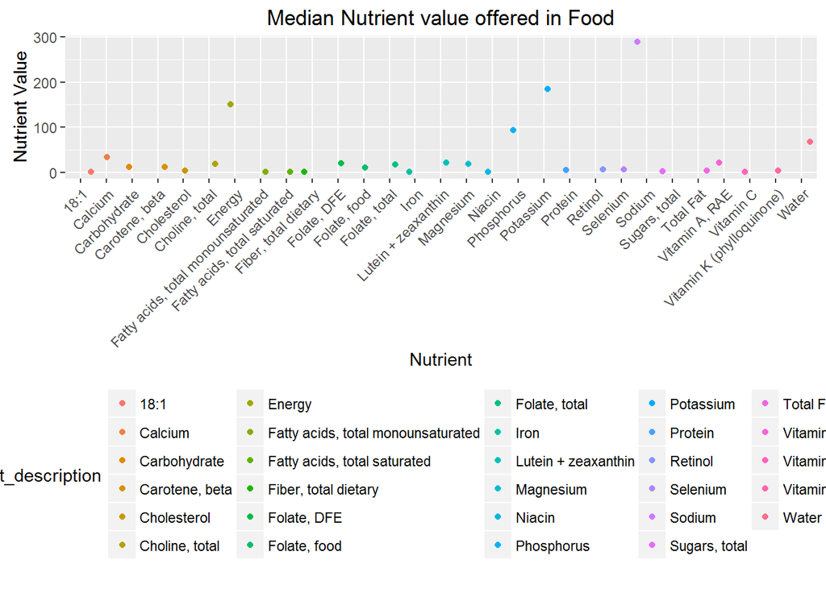

```r
library(ggplot2)
g <- ggplot(data = res1)
g+ geom_jitter(aes(x = nutrient_description, y = median_value,
                   color = nutrient_description)) +
  theme(legend.position="bottom", legend.direction="horizontal",
        axis.text.x = element_text(angle = 45, hjust=1)) +
  ggtitle("Median Nutrient value offered in Food") + labs(x = "Nutrient",
        y = "Nutrient Value")
```

Now, let us analyze what foods Energy, Phosphorus, Potassium and Sodium are present in:

```r
#Food items with Energy as non-zero
res1energy <- sqldf("SELECT mfd.main_food_description, nd.nutrient_description,
                  nv.nutrient_value, mfd.fortification_id, nd.unit
              FROM MainFoodDesc mfd
              INNER JOIN FNDDSNutVal nv ON mfd.food_code = nv.food_code
              INNER JOIN NutDesc nd ON nv.nutrient_code = nd.nutrient_code
              WHERE nd.nutrient_description = 'Energy'
              ")
print("Food items with Energy")
```

```
## [1] "Food items with Energy"
```

```r
print(head(res1energy))
```

```
##                           main_food_description nutrient_description
## 1                                   Milk, human               Energy
## 2                                     Milk, NFS               Energy
## 3                     Milk, cow's, fluid, whole               Energy
## 4         Milk, cow's, fluid, whole, low-sodium               Energy
## 5  Milk, calcium fortified, cow's, fluid, whole               Energy
## 6 Milk, calcium fortified, cow's, fluid, 1% fat               Energy
##   nutrient_value fortification_id unit
## 1             70                0 kcal
## 2             50                1 kcal
## 3             61                1 kcal
## 4             61                1 kcal
## 5             61                1 kcal
## 6             42                1 kcal
```

```r
#Food items with Phosphorus as non-zero
res1phosphorus <- sqldf("SELECT mfd.main_food_description, nd.nutrient_description,
                  nv.nutrient_value, mfd.fortification_id, nd.unit
                    FROM MainFoodDesc mfd
                    INNER JOIN FNDDSNutVal nv ON mfd.food_code = nv.food_code
                    INNER JOIN NutDesc nd ON nv.nutrient_code = nd.nutrient_code
                    WHERE nd.nutrient_description = 'Phosphorus'
                    ")
print("Food items with Phosphorus")
```

```
## [1] "Food items with Phosphorus"
```

```r
print(head(res1phosphorus))
```

```
##                           main_food_description nutrient_description
## 1                                   Milk, human           Phosphorus
## 2                                     Milk, NFS           Phosphorus
## 3                     Milk, cow's, fluid, whole           Phosphorus
## 4         Milk, cow's, fluid, whole, low-sodium           Phosphorus
## 5  Milk, calcium fortified, cow's, fluid, whole           Phosphorus
## 6 Milk, calcium fortified, cow's, fluid, 1% fat           Phosphorus
##   nutrient_value fortification_id unit
## 1             14                0   mg
## 2             91                1   mg
## 3             84                1   mg
## 4             86                1   mg
## 5             84                1   mg
## 6             95                1   mg
```

```r
#Food items with Potassium as non-zero
res1potassium <- sqldf("SELECT mfd.main_food_description, nd.nutrient_description,
                  nv.nutrient_value, mfd.fortification_id, nd.unit
                        FROM MainFoodDesc mfd
                        INNER JOIN FNDDSNutVal nv ON mfd.food_code = nv.food_code
                        INNER JOIN NutDesc nd ON nv.nutrient_code = nd.nutrient_code
                        WHERE nd.nutrient_description = 'Potassium'
                        ")
print("Food items with Potassium")
```

```
## [1] "Food items with Potassium"
```

```r
print(head(res1potassium))
```

```
##                           main_food_description nutrient_description
## 1                                   Milk, human            Potassium
## 2                                     Milk, NFS            Potassium
## 3                     Milk, cow's, fluid, whole            Potassium
## 4         Milk, cow's, fluid, whole, low-sodium            Potassium
## 5  Milk, calcium fortified, cow's, fluid, whole            Potassium
## 6 Milk, calcium fortified, cow's, fluid, 1% fat            Potassium
##   nutrient_value fortification_id unit
## 1             51                0   mg
## 2            142                1   mg
## 3            132                1   mg
## 4            253                1   mg
## 5            132                1   mg
## 6            150                1   mg
```

```r
#Food items with Potassium as non-zero
res1sodium <- sqldf("SELECT mfd.main_food_description, nd.nutrient_description,
                  nv.nutrient_value, mfd.fortification_id, nd.unit
                       FROM MainFoodDesc mfd
                       INNER JOIN FNDDSNutVal nv ON mfd.food_code = nv.food_code
                       INNER JOIN NutDesc nd ON nv.nutrient_code = nd.nutrient_code
                       WHERE nd.nutrient_description = 'Sodium'
                       ")
print("Food items with Potassium")
```

```
## [1] "Food items with Potassium"
```

```r
print(head(res1potassium))
```

```
##                           main_food_description nutrient_description
## 1                                   Milk, human            Potassium
## 2                                     Milk, NFS            Potassium
## 3                     Milk, cow's, fluid, whole            Potassium
## 4         Milk, cow's, fluid, whole, low-sodium            Potassium
## 5  Milk, calcium fortified, cow's, fluid, whole            Potassium
## 6 Milk, calcium fortified, cow's, fluid, 1% fat            Potassium
##   nutrient_value fortification_id unit
## 1             51                0   mg
## 2            142                1   mg
## 3            132                1   mg
## 4            253                1   mg
## 5            132                1   mg
## 6            150                1   mg
```

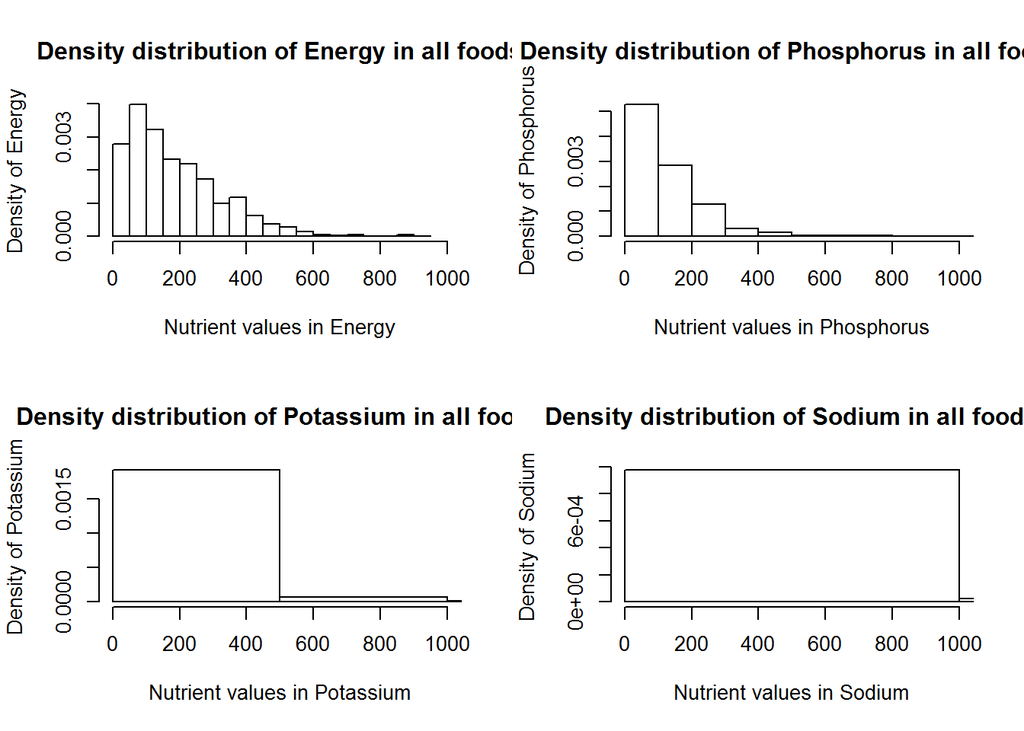

```r
par(mfrow= c(2,2))
hist(res1energy$nutrient_value, probability = TRUE,
     xlab = "Nutrient values in Energy", ylab = "Density of Energy", xlim = c(0,1000),
     main = "Density distribution of Energy in all foods")

hist(res1phosphorus$nutrient_value, probability = TRUE,
     xlab = "Nutrient values in Phosphorus", ylab = "Density of Phosphorus", xlim = c(0,1000),
     main = "Density distribution of Phosphorus in all foods")

hist(res1potassium$nutrient_value, probability = TRUE,
     xlab = "Nutrient values in Potassium", ylab = "Density of Potassium", xlim = c(0,1000),
     main = "Density distribution of Potassium in all foods")

hist(res1sodium$nutrient_value, probability = TRUE,
     xlab = "Nutrient values in Sodium", ylab = "Density of Sodium", xlim = c(0,1000),
     main = "Density distribution of Sodium in all foods")
```

Now finding **food categories** which provide these 4 nutrients:

```r
fcode_nut_catg_subset <- subset(fcode_nut_catg, fcode_nut_catg$Sodium>0 |
                                  fcode_nut_catg$Potassium>0 |
                                  fcode_nut_catg$Phosphorus>0 |
                                  fcode_nut_catg$Energy>0)
print("Only foods with Sodium, Potassium, Phosphorus and Energy")
```

```
## [1] "Only foods with Sodium, Potassium, Phosphorus and Energy"
```

```r
print(head(fcode_nut_catg_subset))
```

```
##   Alcohol Caffeine Calcium Carbohydrate Carotene, alpha Carotene, beta
## 1       0        0     119         4.85               0              4
## 2       0        0     128        23.60               0             19
## 3       0        2      51        23.01               0              0
## 4       0        0     950         3.82               0             97
## 5       0        0       8         0.00               0              0
## 6       0        0      23         0.00               0              0
##   Cholesterol Choline, total Copper Cryptoxanthin, beta Energy
## 1           7           15.8  0.014                   0     50
## 2          44           26.0  0.023                   0    207
## 3           1            9.5  0.092                   0    142
## 4          87           22.0  0.032                   9    338
## 5          85          112.9  0.123                   0    209
## 6          88           80.5  0.081                   0    258
##   Fatty acids, total monounsaturated Fatty acids, total polyunsaturated
```

[output cut: 55 more lines]

Showing the plots of each of these nutrients split by the food categories: 1.

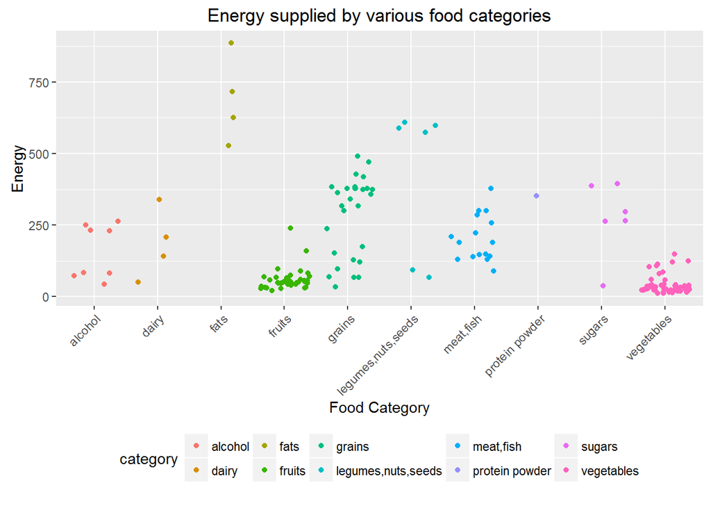

```r
par(mfrow= c(1,1))

g <- ggplot(data = fcode_nut_catg_subset)
g + geom_jitter(aes(x =category, y = Energy, color = category)) + xlab("Food Category")+
    ggtitle("Energy supplied by various food categories") +  theme(legend.position="bottom", legend.direction="horizontal",
        axis.text.x = element_text(angle = 45, hjust=1))
```

Fats give the most energy, closely followed by legumes,nuts and seeds. Grains show a wide spread of energy contribution to the diet. Vegetables and fruits give the least energy

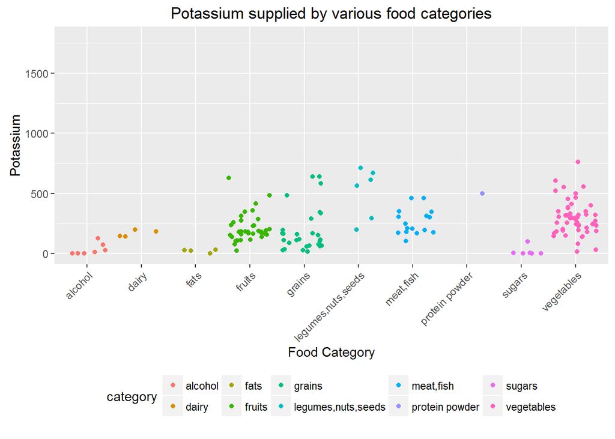

```r
g + geom_jitter(aes(x =category, y = Potassium, color = category))+
  ylim(0,1800)  + xlab("Food Category")+
  ggtitle("Potassium supplied by various food categories") + theme(legend.position="bottom", legend.direction="horizontal",
        axis.text.x = element_text(angle = 45, hjust=1))
```

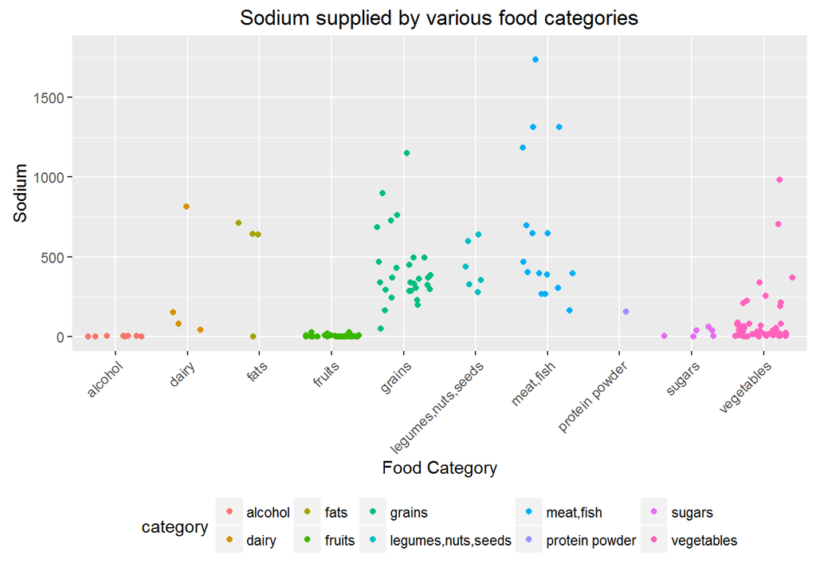

```r
g + geom_jitter(aes(x =category, y = Sodium, color = category))+
  ylim(0,1800) + xlab("Food Category")+
    ggtitle("Sodium supplied by various food categories")+
  theme(legend.position="bottom", legend.direction="horizontal",
        axis.text.x = element_text(angle = 45, hjust=1))
```

Grains and meat & fish give the most Sodium

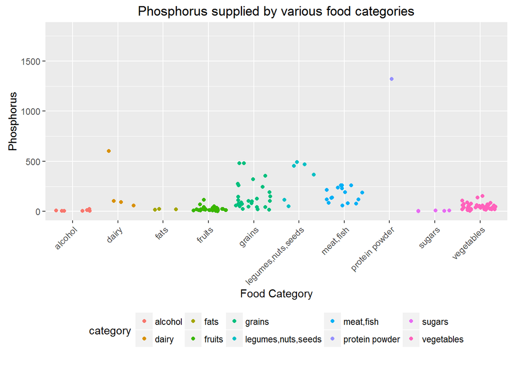

```r
g + geom_jitter(aes(x =category, y = Phosphorus, color = category))+
  ylim(0,1800) +  xlab("Food Category")+
    ggtitle("Phosphorus supplied by various food categories") +  theme(legend.position="bottom", legend.direction="horizontal",
        axis.text.x = element_text(angle = 45, hjust=1))
```

**It has alsp been seen that the original dataset also gives a similar composition.**

## Part-2 of Exploratory Analysis

**Cheking if items which are fortified have higher nutrients than those which are not**

Number of food items which are/are not fortified

```r
res2 <- sqldf("SELECT fortification_id, count(*) fortified_items
              FROM MainFoodDesc
              GROUP BY fortification_id
              ORDER BY fortified_items DESC
              ")
print("Number of items which are fortified, according to fortification id:")
```

```
## [1] "Number of items which are fortified, according to fortification id:"
```

```r
print(res2)
```

```
##   fortification_id fortified_items
## 1                0            5271
## 2                2            1462
## 3                1             885
```

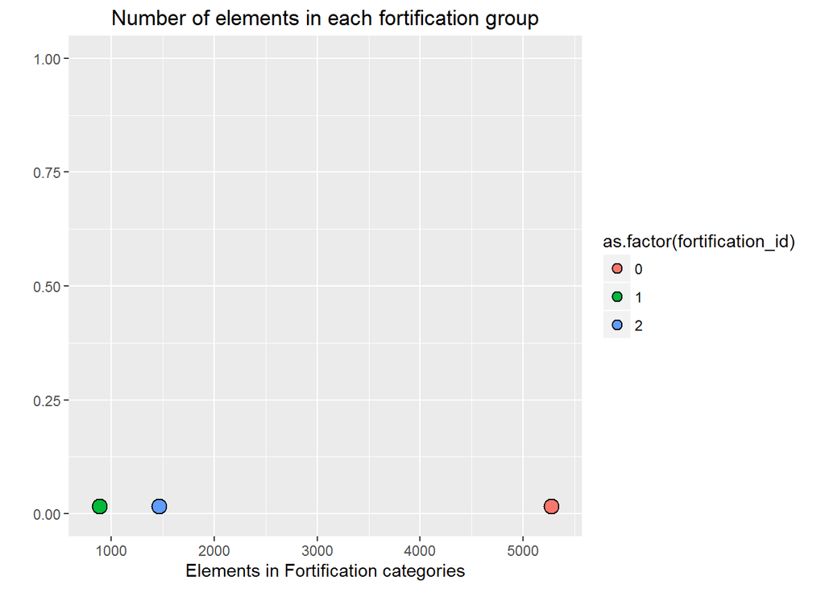

```r
g<- ggplot(res2)
g+geom_dotplot(aes(fortified_items, fill= as.factor(fortification_id)))+
               xlab("Elements in Fortification categories")+ ylab("")+
  ggtitle("Number of elements in each fortification group")
```

Non-Fortified food items:

```r
res2_not_fortified <- sqldf("SELECT category, sum(Energy) total_Energy,
                              sum(Potassium) total_Potassium,
                              sum(Sodium) total_Sodium,
                              sum(Phosphorus) total_Phosphorus
                            FROM fcode_nut_catg
                            WHERE food_code IN (SELECT food_code from MainFoodDesc
                                                WHERE fortification_id = 0)
                            GROUP BY category
                            ")
print("Non-Fortified Items")
```

```
## [1] "Non-Fortified Items"
```

```r
print(head(res2_not_fortified))
```

```
##             category total_Energy total_Potassium total_Sodium
## 1            alcohol         1258             246           22
## 2              dairy          207             199           80
## 3               fats         1603              24          643
## 4             fruits         2119            7435          146
## 5             grains         3363            1507         6139
## 6 legumes,nuts,seeds         2531            3056         2639
##   total_Phosphorus
## 1               80
## 2              105
## 3               24
## 4              819
## 5             1243
## 6             1949
```

Fortified food items:

```r
res2_fortified <- sqldf("SELECT category, sum(Energy) total_Energy,
                            sum(Potassium) total_Potassium,
                            sum(Sodium) total_Sodium,
                            sum(Phosphorus) total_Phosphorus
                            FROM fcode_nut_catg
                            WHERE food_code IN (SELECT food_code from MainFoodDesc
                                                WHERE fortification_id BETWEEN 1 AND 2)
                            GROUP BY category
                            ")
print("Fortified Items")
```

```
## [1] "Fortified Items"
```

```r
print(res2_fortified)
```

```
##         category total_Energy total_Potassium total_Sodium
## 1          dairy          530             473         1012
## 2           fats         1153              57         1354
## 3         fruits           96             317            5
## 4         grains         4611            3906         5622
## 5 protein powder          352             500          156
## 6     vegetables          269            1122          839
##   total_Phosphorus
## 1              750
## 2               36
## 3               47
## 4             2840
## 5             1321
## 6              152
```

Foods which are Fortified are: 1. Dairy 2. Fats 3. Fruits 4. Grains 5. Protein powder 6. Vegetables

We will now analyze these two categories of foood items and understand their nutrient composition: 1. Fortified Foods 2. Non-Fortified Foods

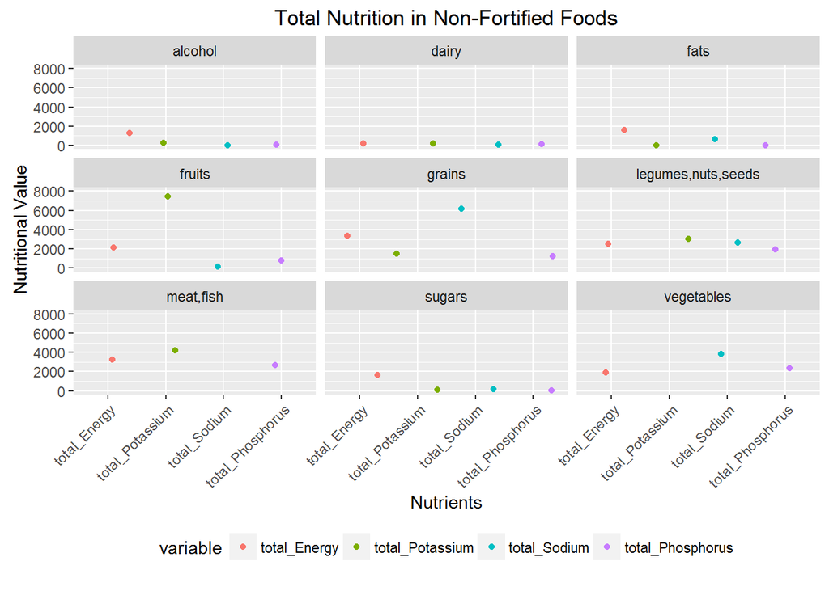

```r
library(reshape2)

res2_not_fortified_melt <- melt(res2_not_fortified, id.vars = "category")
g_notfort<- ggplot(data = res2_not_fortified_melt)
g_notfort + geom_jitter(aes(x =variable, y = value, color = variable))+
  xlab("Nutrients") + ylab("Nutritional Value")+ ylim(0,8000)+
  facet_wrap(~category) + ggtitle("Total Nutrition in Non-Fortified Foods") +
  theme(legend.position="bottom", legend.direction="horizontal",
        axis.text.x = element_text(angle = 45, hjust=1))
```

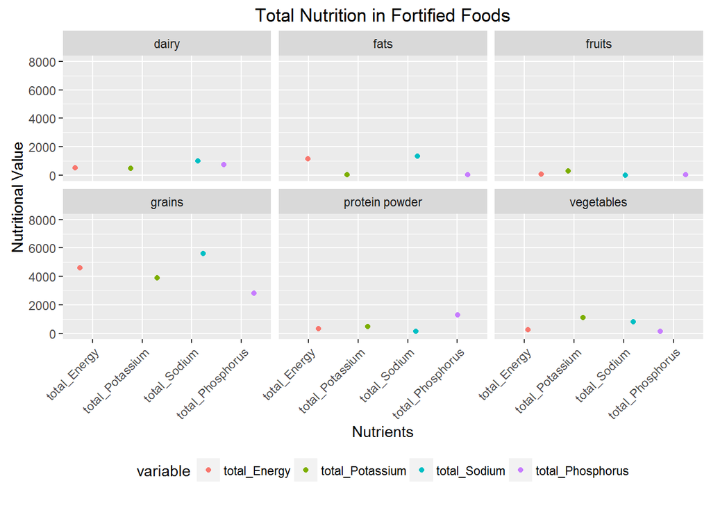

```r
res2_fortified_melt <- melt(res2_fortified, id.vars = "category")
g_fort <- ggplot(data = res2_fortified_melt)
g_fort + geom_jitter(aes(x =variable, y = value, color = variable))+
  xlab("Nutrients") + ylab("Nutritional Value") + ylim(0,8000)+
  facet_wrap(~category) + ggtitle("Total Nutrition in Fortified Foods")+
  theme(legend.position="bottom", legend.direction="horizontal",
        axis.text.x = element_text(angle = 45, hjust=1))
```

## Part-3: Understanding the food categories in the generated dataset

Number of items in each food_category:

```r
res3 <- sqldf("SELECT DISTINCT(category), count(*) food_categories
              FROM fcode_nut_catg
              GROUP BY category
              ORDER BY food_categories ASC
              ")
print(res3)
```

```
##              category food_categories
## 1      protein powder               1
## 2               dairy               4
## 3                fats               4
## 4  legumes,nuts,seeds               6
## 5              sugars               6
## 6             alcohol               8
## 7           meat,fish              16
## 8              grains              28
## 9              fruits              37
## 10         vegetables              53
```

Total number of food items in the generated dataset:

```r
total_foods <- sqldf("SELECT sum(food_categories) total_food_items FROM res3")
print(total_foods)
```

```
##   total_food_items
## 1              163
```

Minimum, maximum and average nutrients of each food_category in the data set:

```r
res4 <- sqldf("SELECT fng.category food_category,
                  nd.nutrient_description nutrient,
                  min(fnv.nutrient_value) min_nutrients,
                  max(fnv.nutrient_value) max_nutrients,
                  avg(fnv.nutrient_value) avg_nutrients
              FROM fcode_nut_catg fng
              INNER JOIN FNDDSNutVal fnv ON fnv.food_code = fng.food_code
              INNER JOIN NutDesc nd ON fnv.nutrient_code = nd.nutrient_code
              GROUP BY food_category, nutrient
              ")
print(res4)
```

```
##          food_category                           nutrient min_nutrients
## 1              alcohol                               10:0         0.000
## 2              alcohol                               12:0         0.000
## 3              alcohol                               14:0         0.000
## 4              alcohol                               16:0         0.000
## 5              alcohol                               16:1         0.000
## 6              alcohol                               18:0         0.000
## 7              alcohol                               18:1         0.000
## 8              alcohol                               18:2         0.000
## 9              alcohol                               18:3         0.000
## 10             alcohol                               18:4         0.000
## 11             alcohol                               20:1         0.000
## 12             alcohol                               20:4         0.000
## 13             alcohol                           20:5 n-3         0.000
## 14             alcohol                               22:1         0.000
```

[output cut: 1287 more lines]

Selecting known nutrients only. i.e. removing nutrients with numerical headers (no description)

```r
res4_nut_categ <- sqldf("SELECT fng.category food_category,
                    nd.nutrient_description nutrient,
                    fnv.nutrient_value nutrient_value
                    FROM fcode_nut_catg fng
                    INNER JOIN FNDDSNutVal fnv ON fnv.food_code = fng.food_code
                    INNER JOIN (SELECT nutrient_code, nutrient_description FROM NutDesc
                                WHERE nutrient_code NOT BETWEEN 607 and 631
                    )nd ON fnv.nutrient_code = nd.nutrient_code
                   ")
```

Selecting food_codes and descriptions for foods where the description starts with milk.

```r
milk_desc <- sqldf("SELECT food_code, main_food_description
                   FROM MainFoodDesc
                   WHERE main_food_description LIKE 'Milk%'")
print(head(milk_desc))
```

```
##   food_code                         main_food_description
## 1  11000000                                   Milk, human
## 2  11100000                                     Milk, NFS
## 3  11111000                     Milk, cow's, fluid, whole
## 4  11111100         Milk, cow's, fluid, whole, low-sodium
## 5  11111150  Milk, calcium fortified, cow's, fluid, whole
## 6  11111160 Milk, calcium fortified, cow's, fluid, 1% fat
```

Selecting all nutrients which have some form of vitamin in them

```r
vitamin_desc <- sqldf("SELECT nutrient_code, nutrient_description
                   FROM NutDesc
                   WHERE nutrient_description LIKE '%Vitamin%'")
print(head(vitamin_desc))
```

```
##   nutrient_code         nutrient_description
## 1           320               Vitamin A, RAE
## 2           323 Vitamin E (alpha-tocopherol)
## 3           328          Vitamin D (D2 + D3)
## 4           401                    Vitamin C
## 5           415                  Vitamin B-6
## 6           418                 Vitamin B-12
```

```r
count_nuts <- sqldf("SELECT count(DISTINCT(nutrient_code)) FROM vitamin_desc")
print(count_nuts)
```

```
##   count(DISTINCT(nutrient_code))
## 1                              9
```

There are 9 different types of vitamins in our data frame.

Selecting all nutrients which have “a” as the second alphabet in the code

```r
a_desc <- sqldf("SELECT nutrient_code, nutrient_description
                   FROM NutDesc
                   WHERE nutrient_description LIKE '_a%'")
print(head(a_desc))
```

```
##   nutrient_code nutrient_description
## 1           205         Carbohydrate
## 2           255                Water
## 3           262             Caffeine
## 4           301              Calcium
## 5           304            Magnesium
## 6           321       Carotene, beta
```

```r
count_a <- sqldf("SELECT count(DISTINCT(nutrient_code)) FROM a_desc")
print(count_a)
```

```
##   count(DISTINCT(nutrient_code))
## 1                             10
```

There are 10 nutrients with “a”" as the second alphabet.

Now using boxplots to see the spread of nutrient value in each food category and each nutrient:

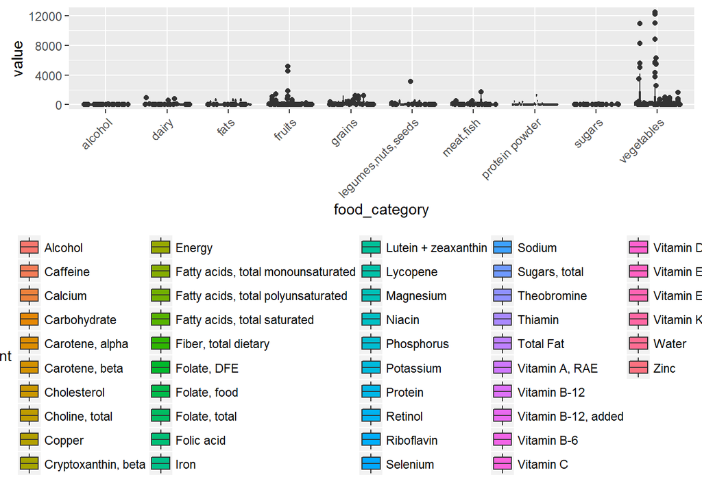

```r
res4_nut_categ_melted <- melt(data = res4_nut_categ,
                              id = c("food_category", "nutrient"))
g_res4 <- ggplot(data = res4_nut_categ_melted)
g_res4 + geom_boxplot(aes(x=food_category, y=value, fill=nutrient)) +
  theme(legend.position="bottom", legend.direction="horizontal",
        axis.text.x = element_text(angle = 45, hjust=1))
```

Plotting nutrients in ‘alcohol’, ‘dairy’, ‘fats’ and ‘grains’:

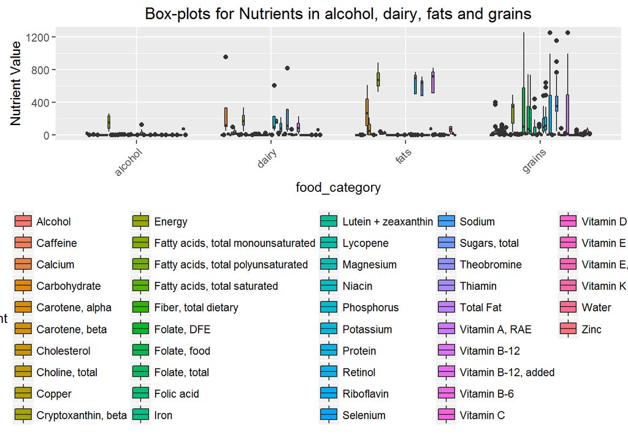

```r
res41 <- sqldf("SELECT fng.category food_category,
                    nd.nutrient_description nutrient,
                        fnv.nutrient_value nutrient_value
                        FROM fcode_nut_catg fng
                        INNER JOIN FNDDSNutVal fnv ON fnv.food_code = fng.food_code
                        INNER JOIN (SELECT nutrient_code, nutrient_description FROM NutDesc
                        WHERE nutrient_code NOT BETWEEN 607 and 631
                        )nd ON fnv.nutrient_code = nd.nutrient_code
                        WHERE food_category IN ('alcohol', 'dairy', 'fats', 'grains')
                        ")
res41_melted <- melt(data = res41, id = c("food_category", "nutrient"))
g_res41_nooutlier <- ggplot(data = res41_melted)
g_res41_nooutlier + geom_boxplot(aes(x=food_category, y=value, fill=nutrient)) +
   theme(legend.position="bottom", legend.direction="horizontal",
        axis.text.x = element_text(angle = 45, hjust=1)) + ylab("Nutrient Value") +
  ggtitle("Box-plots for Nutrients in alcohol, dairy, fats and grains")
```

Plotting nutrients in ‘fruits’, ‘legumes,nuts,seeds’, ‘meat,fish’:

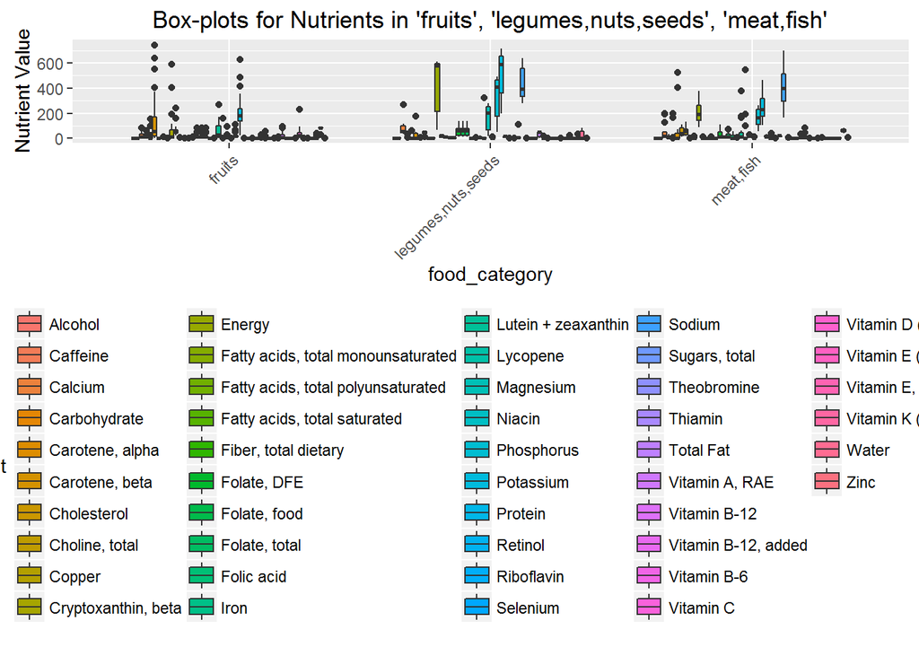

```r
res42 <- sqldf("SELECT fng.category food_category,
                    nd.nutrient_description nutrient,
               fnv.nutrient_value nutrient_value
               FROM fcode_nut_catg fng
               INNER JOIN FNDDSNutVal fnv ON fnv.food_code = fng.food_code
               INNER JOIN (SELECT nutrient_code, nutrient_description FROM NutDesc
               WHERE nutrient_code NOT BETWEEN 607 and 631
               )nd ON fnv.nutrient_code = nd.nutrient_code
               WHERE food_category IN ('fruits','legumes,nuts,seeds', 'meat,fish' )
               ")
res42_melted <- melt(data = res42, id = c("food_category", "nutrient"))
g_res42_nooutlier <- ggplot(data = res42_melted)
g_res42_nooutlier + geom_boxplot(aes(x=food_category, y=value, fill=nutrient)) +
  theme(legend.position="bottom", legend.direction="horizontal",
        axis.text.x = element_text(angle = 45, hjust=1)) + ylab("Nutrient Value") +
  ggtitle("Box-plots for Nutrients in 'fruits', 'legumes,nuts,seeds', 'meat,fish'") +
  ylim(0,750)
```

Plotting nutrients in ‘protein powder’,‘sugars’, ‘vegetables’:

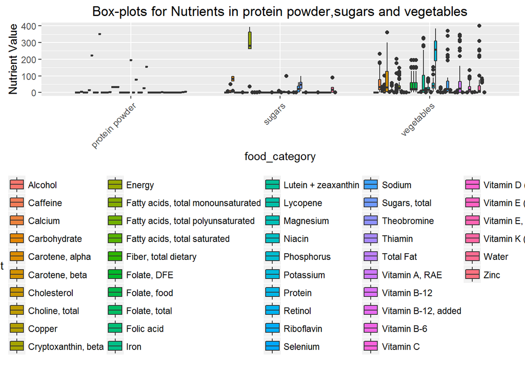

```r
res43 <- sqldf("SELECT fng.category food_category,
                    nd.nutrient_description nutrient,
               fnv.nutrient_value nutrient_value
               FROM fcode_nut_catg fng
               INNER JOIN FNDDSNutVal fnv ON fnv.food_code = fng.food_code
               INNER JOIN (SELECT nutrient_code, nutrient_description FROM NutDesc
               WHERE nutrient_code NOT BETWEEN 607 and 631
               )nd ON fnv.nutrient_code = nd.nutrient_code
               WHERE food_category IN ('protein powder','sugars', 'vegetables' )
               ")
res43_melted <- melt(data = res43, id = c("food_category", "nutrient"))
g_res43_nooutlier <- ggplot(data = res43_melted)
g_res43_nooutlier + geom_boxplot(aes(x=food_category, y=value, fill=nutrient)) +
  theme(legend.position="bottom", legend.direction="horizontal",
        axis.text.x = element_text(angle = 45, hjust=1)) + ylab("Nutrient Value") +
  ggtitle("Box-plots for Nutrients in protein powder,sugars and vegetables") +
  ylim(0,400)
```

## Part-4 ALL Food and ALL nutrient Analysis

Now for **all foods and all nutrients** Finding Nutrition in foods which are fortified v/s food which are not

```r
res5 <- sqldf("SELECT *
              FROM fcode_nut_catg
              INNER JOIN (SELECT food_code FROM
                          MainFoodDesc
                          WHERE fortification_id>0) mfd
              ON fcode_nut_catg.food_code = mfd.food_code
            ")
#removing food codes from res5
res5 <- res5[-c(ncol(res5), ncol(res5)-2)]

print("Fortified foods:")
```

```
## [1] "Fortified foods:"
```

```r
print(head(res5))
```

```
##   Alcohol Caffeine Calcium Carbohydrate Carotene, alpha Carotene, beta
## 1       0        0     119         4.85               0              4
## 2       0        2      51        23.01               0              0
## 3       0        0     950         3.82               0             97
## 4       0        0      61        64.40               6             17
## 5       0        0      41        72.90               0              0
## 6       0        0      80        11.67               0              0
##   Cholesterol Choline, total Copper Cryptoxanthin, beta Energy
## 1           7           15.8  0.014                   0     50
## 2           1            9.5  0.092                   0    142
## 3          87           22.0  0.032                   9    338
## 4           0           22.0  0.392                   0    471
## 5           0           34.3  0.100                   0    377
## 6           0            4.7  0.066                   0     68
##   Fatty acids, total monounsaturated Fatty acids, total polyunsaturated
```

[output cut: 55 more lines]

```r
res6 <- sqldf("SELECT *
              FROM fcode_nut_catg
              INNER JOIN (SELECT food_code FROM
              MainFoodDesc
              WHERE fortification_id == 0) mfd
              ON fcode_nut_catg.food_code = mfd.food_code
              ")
#removing food codes from res6
res6 <- res6[-c(ncol(res6), ncol(res6)-2)]
print("Non-Fortified foods:")
```

```
## [1] "Non-Fortified foods:"
```

```r
print(head(res5))
```

[output not shown]

[output cut: 55 more lines]

Plot on same grid, each nutrient colored differently

```r
library(reshape2)
df5 <- melt(res5 )
df6 <- melt(res6)
```

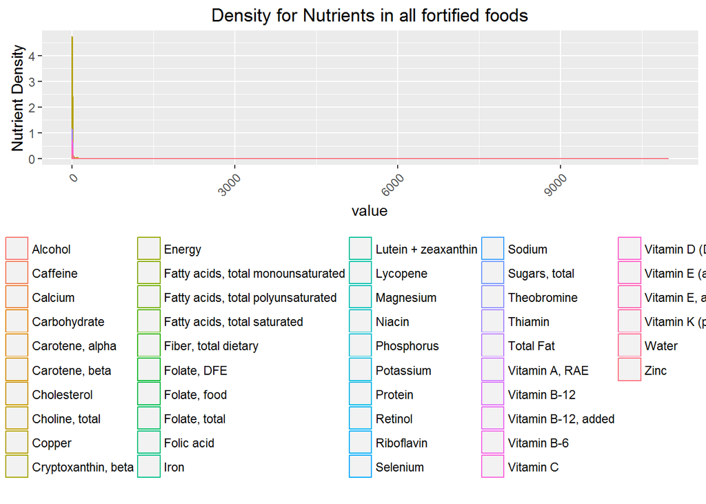

```r
ggplot(df5, aes(x = value)) + geom_density(aes(color=variable)) +
  theme(legend.position="bottom", legend.direction="horizontal",
        axis.text.x = element_text(angle = 45, hjust=1))+ ylab("Nutrient Density") +
  ggtitle("Density for Nutrients in all fortified foods")
```

Zooming in on xlim 0-50 to see it closely

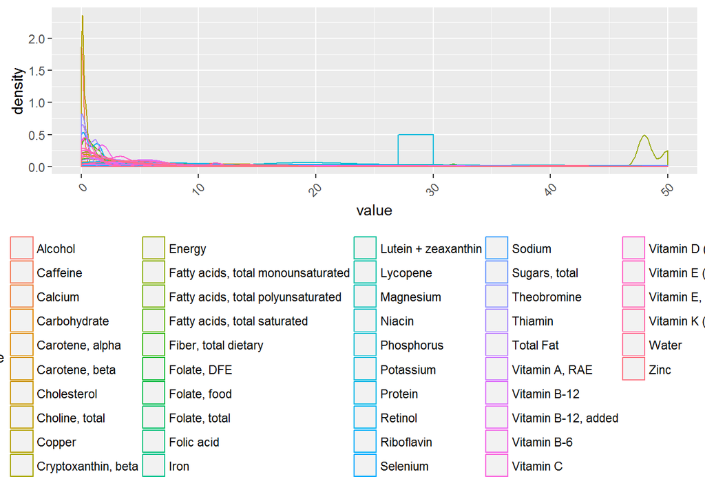

```r
ggplot(df5, aes(x = value)) + geom_density(aes(color=variable)) +
  theme(legend.position="bottom", legend.direction="horizontal",
        axis.text.x = element_text(angle = 45, hjust=1)) + xlim(0,50)
```

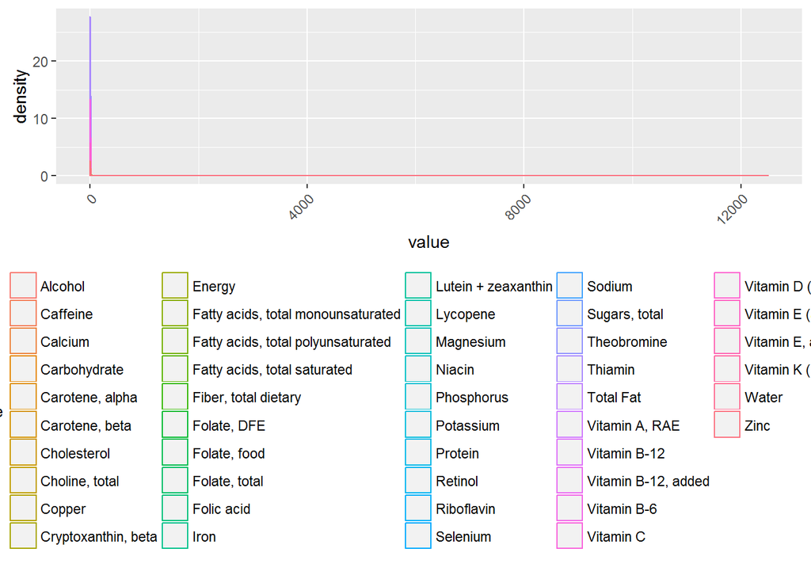

```r
ggplot(df6, aes(x = value)) + geom_density(aes(color=variable)) +
  theme(legend.position="bottom", legend.direction="horizontal",
        axis.text.x = element_text(angle = 45, hjust=1))
```

Zooming in in xlim 0-10 to see it closely

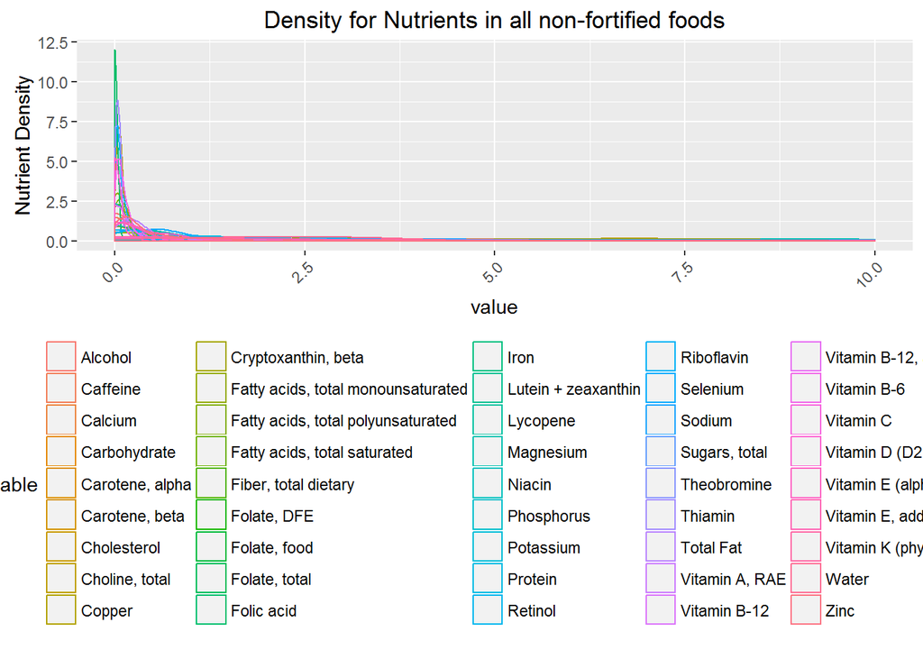

```r
ggplot(df6, aes(x = value)) + geom_density(aes(color=variable)) +
  theme(legend.position="bottom", legend.direction="horizontal",
        axis.text.x = element_text(angle = 45, hjust=1)) + xlim(0,10)+
  ylab("Nutrient Density") +
  ggtitle("Density for Nutrients in all non-fortified foods")
```

#### Summarizing overall data

```r
print(summary(fcode_nut_catg))
```

```
##     Alcohol          Caffeine          Calcium        Carbohydrate
##  Min.   : 0.000   Min.   : 0.0000   Min.   :  0.00   Min.   : 0.00
##  1st Qu.: 0.000   1st Qu.: 0.0000   1st Qu.:  9.00   1st Qu.: 4.91
##  Median : 0.000   Median : 0.0000   Median : 22.00   Median : 9.58
##  Mean   : 1.056   Mean   : 0.1595   Mean   : 54.43   Mean   :19.65
##  3rd Qu.: 0.000   3rd Qu.: 0.0000   3rd Qu.: 51.00   3rd Qu.:19.95
##  Max.   :37.900   Max.   :11.0000   Max.   :950.00   Max.   :99.98
##  Carotene, alpha   Carotene, beta     Cholesterol      Choline, total
##  Min.   :   0.00   Min.   :    0.0   Min.   :  0.000   Min.   :  0.00
##  1st Qu.:   0.00   1st Qu.:    0.0   1st Qu.:  0.000   1st Qu.:  6.05
##  Median :   0.00   Median :   29.0   Median :  0.000   Median :  9.80
##  Mean   :  54.98   Mean   :  523.9   Mean   :  8.853   Mean   : 18.66
##  3rd Qu.:   4.00   3rd Qu.:  251.5   3rd Qu.:  0.000   3rd Qu.: 22.00
##  Max.   :3477.00   Max.   :10980.0   Max.   :215.000   Max.   :224.00
##      Copper       Cryptoxanthin, beta     Energy
##  Min.   :0.0000   Min.   :   0.00     Min.   : 11.0
##  1st Qu.:0.0420   1st Qu.:   0.00     1st Qu.: 34.0
##  Median :0.0730   Median :   0.00     Median : 68.0
##  Mean   :0.1313   Mean   :  27.87     Mean   :152.8
##  3rd Qu.:0.1500   3rd Qu.:   1.50     3rd Qu.:238.0
##  Max.   :2.2200   Max.   :1447.00     Max.   :886.0
##  Fatty acids, total monounsaturated Fatty acids, total polyunsaturated
##  Min.   : 0.0000                    Min.   : 0.0000
##  1st Qu.: 0.0185                    1st Qu.: 0.0555
##  Median : 0.0860                    Median : 0.1440
##  Mean   : 2.4454                    Mean   : 1.4888
##  3rd Qu.: 1.0440                    3rd Qu.: 0.5410
##  Max.   :40.4390                    Max.   :43.2770
##  Fatty acids, total saturated Fiber, total dietary  Folate, DFE
##  Min.   : 0.000               Min.   : 0.000       Min.   :   0.00
##  1st Qu.: 0.026               1st Qu.: 0.600       1st Qu.:   6.00
##  Median : 0.071               Median : 1.700       Median :  18.00
##  Mean   : 1.676               Mean   : 2.221       Mean   :  81.44
##  3rd Qu.: 1.123               3rd Qu.: 2.950       3rd Qu.:  57.00
##  Max.   :51.368               Max.   :11.800       Max.   :1256.00
##   Folate, food    Folate, total      Folic acid          Iron
##  Min.   :  0.00   Min.   :  0.00   Min.   :  0.00   Min.   : 0.000
##  1st Qu.:  5.00   1st Qu.:  6.00   1st Qu.:  0.00   1st Qu.: 0.250
##  Median : 14.00   Median : 18.00   Median :  0.00   Median : 0.580
##  Mean   : 23.77   Mean   : 57.69   Mean   : 33.93   Mean   : 2.367
```

[output cut: 43 more lines]

```
##  Max.   :5.0000      Max.   :23.900               Max.   :11.1800
##  Vitamin K (phylloquinone)     Water            Zinc
##  Min.   :   0.0            Min.   : 0.00   Min.   : 0.000
##  1st Qu.:   0.3            1st Qu.:58.71   1st Qu.: 0.105
##  Median :   2.6            Median :83.07   Median : 0.250
##  Mean   :  46.9            Mean   :67.25   Mean   : 1.116
##  3rd Qu.:  13.2            3rd Qu.:89.70   3rd Qu.: 0.795
##  Max.   :1640.0            Max.   :96.73   Max.   :16.730
##    food_code          category
##  Min.   :11100000   Length:163
##  1st Qu.:57175000   Class :character
##  Median :63139010   Mode  :character
##  Mean   :62940429
##  3rd Qu.:75109525
##  Max.   :95230030
```

**Developing the final dataset from the above data frame. This will be used for analysis in SVM and Logistic Regression. We have chose the Vitamin C because it is distinctly present in a lot of fruits. Same goes for Sugar. Vitamin B12, Fat and Energy are supposed to be very significant in vegetables. Sodium, Potasium and Phosphorus, as analyzed in the first par of exploratory analysis are very significantly present in the food overall and can not be ignored. Calcium is a very important component of dairy foods. Iron is a major component of many vegetables. Most vegetables pulses and meat are protein rich. Water content is higher in fruits than in vegetables. Hence, we will continue with these features for the models.**

```r
data_final <- fcode_nut_catg[, c("Calcium", "Carbohydrate", "Energy", "Iron",
                                            "Protein", "Total Fat", "Sugars, total",
                                            "Potassium", "Phosphorus", "Sodium",
                                            "Vitamin C", "Vitamin B-12",
                                            "Vitamin D (D2 + D3)","Water", "category")]
colnames(data_final)<- c("Calcium", "Carbohydrate", "Energy",   "Iron",
                                   "Protein",   "Total_Fat",    "Total_Sugar",  "Potassium",
                                   "Phosphorus",    "Sodium",   "Vitamin_C",    "Vitamin_B12",
                                   "Vitamin_D", "Water", "Category")
```

Final dataset: boxplot distributions

```r
data_final_melt <- melt(data_final)
```

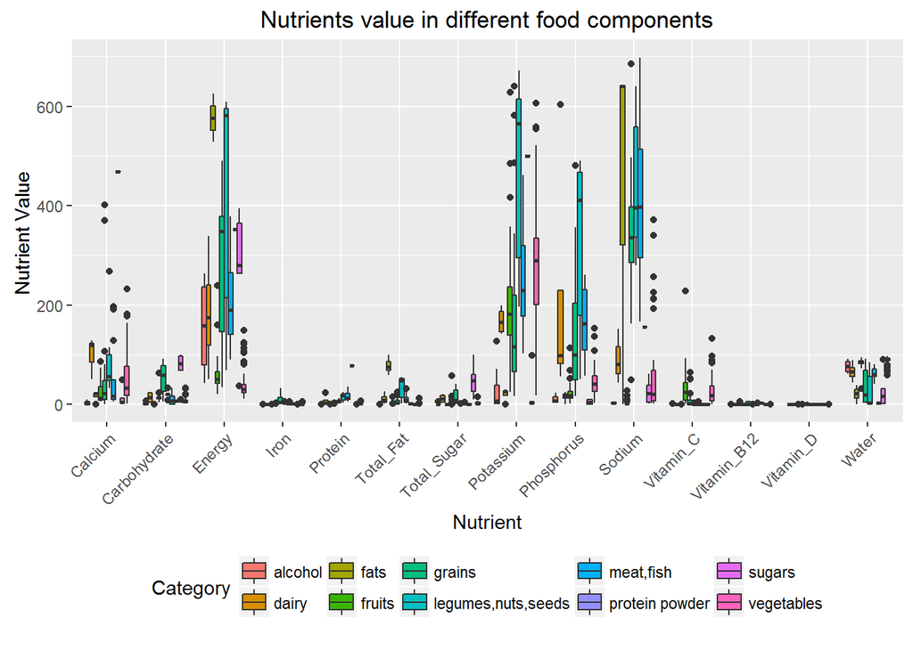

```r
g1 <- ggplot(data = data_final_melt)
g1 + geom_boxplot(aes(x = variable, y = value, fill = Category))+
    ggtitle("Nutrients value in different food components") +
    labs(x="Nutrient",y="Nutrient Value ") + ylim(0,700)+ theme(legend.position="bottom", legend.direction="horizontal",  axis.text.x = element_text(angle = 45, hjust=1))
```

Final dataset summary

```r
print(summary(data_final))
```

```
##     Calcium        Carbohydrate       Energy           Iron
##  Min.   :  0.00   Min.   : 0.00   Min.   : 11.0   Min.   : 0.000
##  1st Qu.:  9.00   1st Qu.: 4.91   1st Qu.: 34.0   1st Qu.: 0.250
##  Median : 22.00   Median : 9.58   Median : 68.0   Median : 0.580
##  Mean   : 54.43   Mean   :19.65   Mean   :152.8   Mean   : 2.367
##  3rd Qu.: 51.00   3rd Qu.:19.95   3rd Qu.:238.0   3rd Qu.: 1.765
##  Max.   :950.00   Max.   :99.98   Max.   :886.0   Max.   :33.300
##     Protein         Total_Fat        Total_Sugar       Potassium
##  Min.   : 0.000   Min.   :  0.000   Min.   : 0.000   Min.   :  0.0
##  1st Qu.: 0.815   1st Qu.:  0.175   1st Qu.: 0.890   1st Qu.:115.5
##  Median : 1.800   Median :  0.420   Median : 3.940   Median :191.0
##  Mean   : 4.750   Mean   :  6.022   Mean   : 8.040   Mean   :231.9
##  3rd Qu.: 4.920   3rd Qu.:  3.485   3rd Qu.: 9.205   3rd Qu.:314.0
##  Max.   :78.130   Max.   :100.000   Max.   :99.800   Max.   :762.0
##    Phosphorus          Sodium         Vitamin_C       Vitamin_B12
##  Min.   :   0.00   Min.   :   0.0   Min.   :  0.00   Min.   :0.0000
##  1st Qu.:  18.50   1st Qu.:   4.0   1st Qu.:  0.10   1st Qu.:0.0000
##  Median :  41.00   Median :  38.0   Median :  5.90   Median :0.0000
##  Mean   :  88.28   Mean   : 204.0   Mean   : 18.35   Mean   :0.5129
##  3rd Qu.:  89.00   3rd Qu.: 331.5   3rd Qu.: 25.95   3rd Qu.:0.0650
##  Max.   :1321.00   Max.   :1737.0   Max.   :228.30   Max.   :7.1000
##    Vitamin_D          Water         Category
##  Min.   :0.0000   Min.   : 0.00   Length:163
##  1st Qu.:0.0000   1st Qu.:58.71   Class :character
##  Median :0.0000   Median :83.07   Mode  :character
##  Mean   :0.2804   Mean   :67.25
##  3rd Qu.:0.0000   3rd Qu.:89.70
##  Max.   :5.0000   Max.   :96.73
```

Min, max, median and interquartile range of all the above nutrients on the basis of food categories

```r
#install.packages("doBy")
library(doBy)
print(summaryBy(.~Category, data=data_final,
          FUN = function(x) c(Minimum=min(x), Mean=mean(x, na.rm = T), Median=median(x),
                              Maximum=max(x), Inter_quartile_range=IQR(x))))
```

```
##              Category Calcium.Minimum Calcium.Mean Calcium.Median
## 1             alcohol               0      3.00000            1.5
## 2               dairy              51    312.00000          123.5
## 3                fats               0     16.75000           21.5
## 4              fruits               5     23.40541           13.0
## 5              grains               0     65.64286           21.5
## 6  legumes,nuts,seeds              33     95.33333           55.5
## 7           meat,fish               5     53.62500           16.5
## 8      protein powder             469    469.00000          469.0
## 9              sugars               1     12.33333            4.0
## 10         vegetables               2     53.88679           33.0
##    Calcium.Maximum Calcium.Inter_quartile_range Carbohydrate.Minimum
## 1                9                         5.00                 0.00
## 2              950                       231.50                 3.82
## 3               24                         6.75                 0.00
```

[output cut: 227 more lines]

Final counts of number of rows by food categories

```r
final_counts <- sqldf("SELECT Category, count(*) Frequency FROM data_final
                      Group by Category
                      ORDER BY Frequency DESC")
print(final_counts)
```

```
##              Category Frequency
## 1          vegetables        53
## 2              fruits        37
## 3              grains        28
## 4           meat,fish        16
## 5             alcohol         8
## 6  legumes,nuts,seeds         6
## 7              sugars         6
## 8               dairy         4
## 9                fats         4
## 10     protein powder         1
```

## Part-5: Final Data Plotting

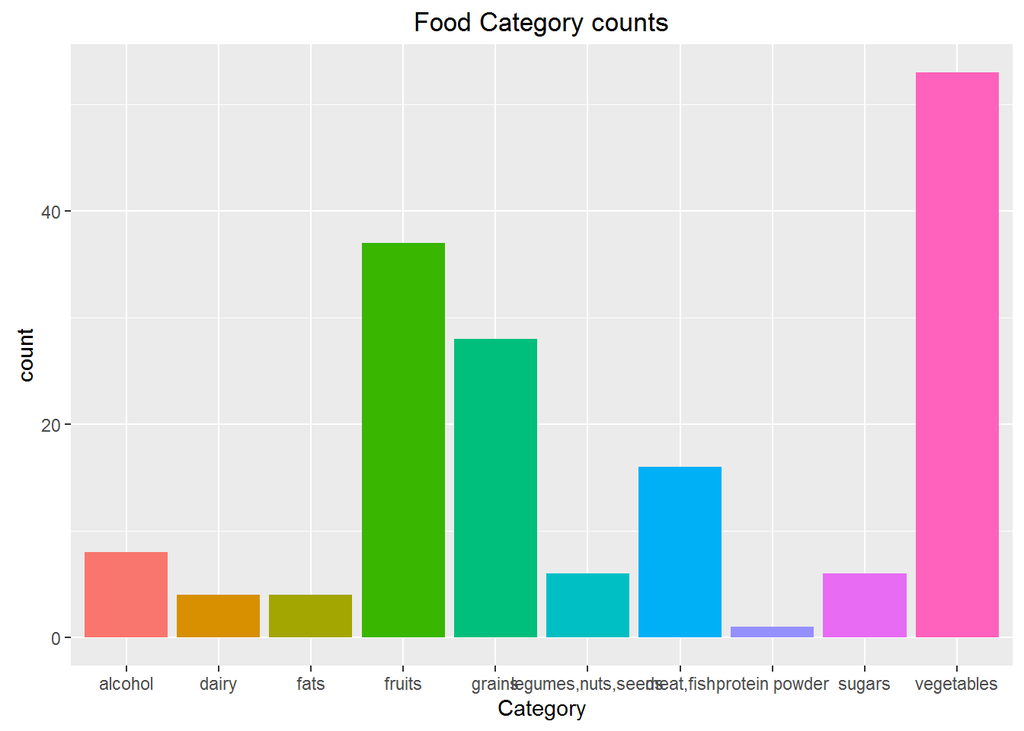

```r
g <- ggplot(data_final,aes(x=Category))
g+geom_bar(aes(fill=Category))+ggtitle("Food Category counts") + theme(legend.position="none")
```

The above figure shows the number of items in every food category.

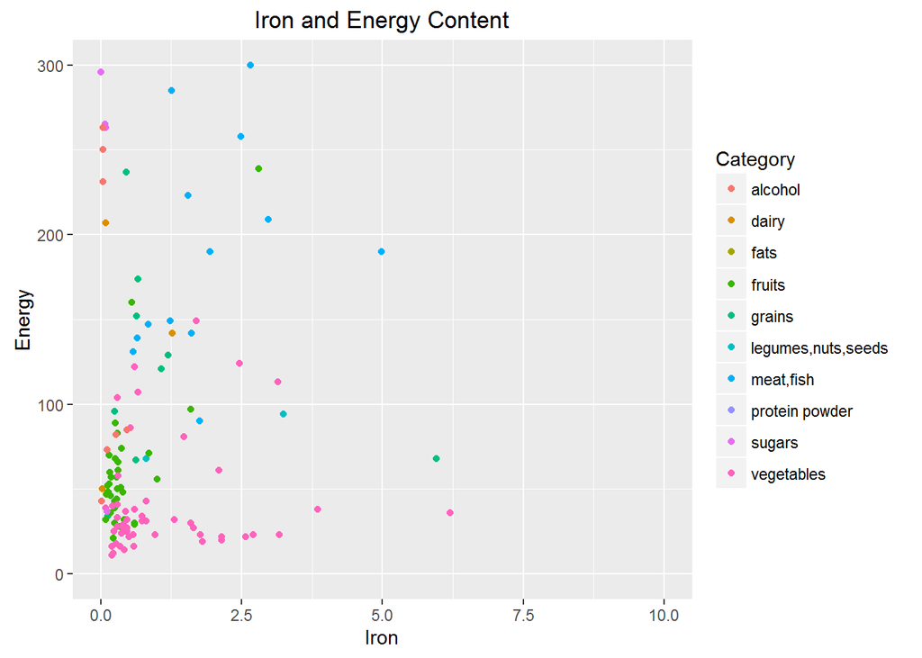

```r
g + geom_point((aes(x=Iron ,y= Energy, color=Category)))+ggtitle("Iron and Energy Content")+
  xlab("Iron")+ylab("Energy") + xlim(0,10) + ylim(0,300)
```

Iron and Energy show no distinctive realtionship between them. However, for vegetables, increase in Iron does not affect energy supplied by the food.

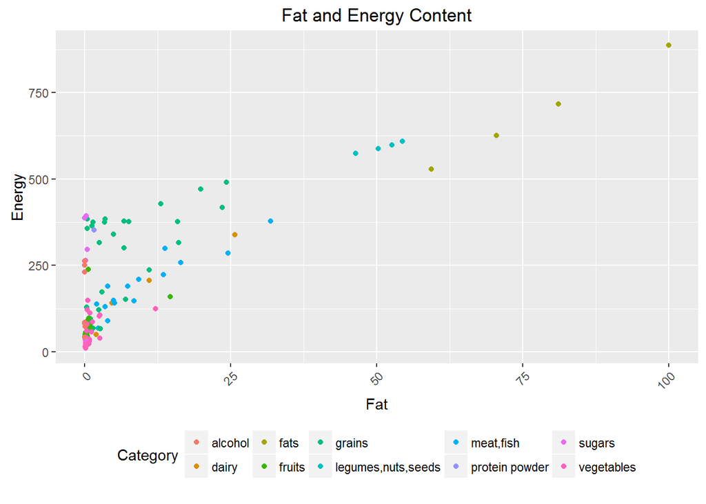

```r
g + geom_point((aes(x=Total_Fat ,y= Energy, color=Category))) + ggtitle("Fat and Energy Content")+
  xlab("Fat")+ylab("Energy") + theme(legend.position="bottom", legend.direction="horizontal", axis.text.x = element_text(angle = 45, hjust=1))
```

Fat and Energy show a slight linear realtionship between them for most categories except for in vegetables, alcohol and dairy.

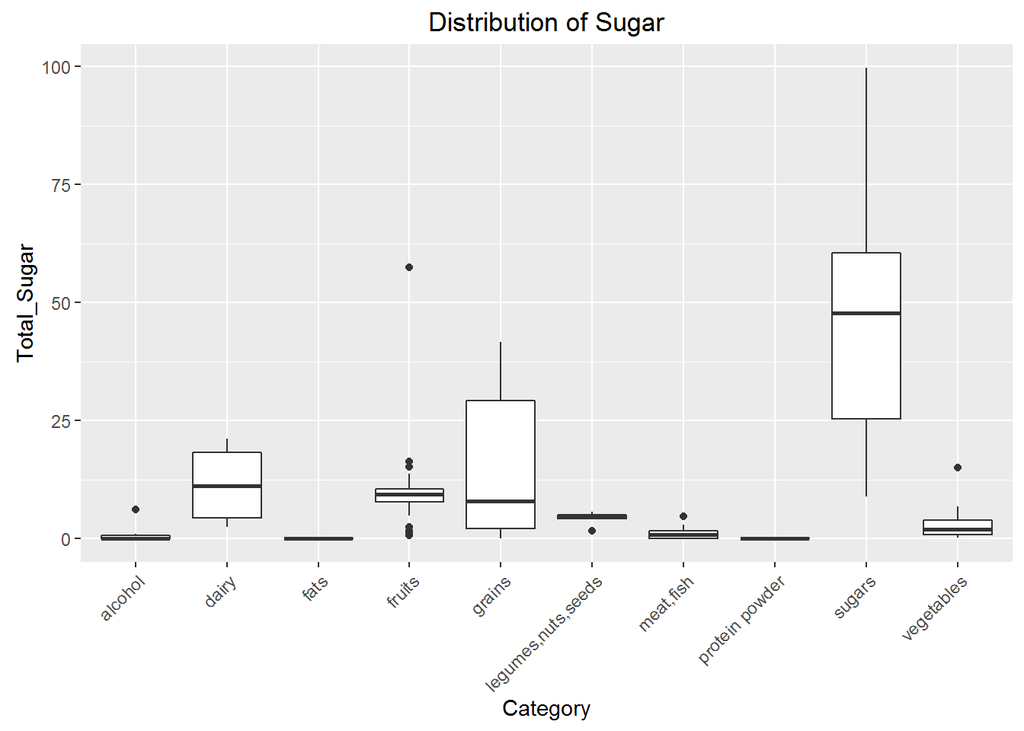

```r
g + geom_boxplot(aes(x=Category,y=Total_Sugar)) + ggtitle("Distribution of Sugar")+ theme(legend.position="bottom", legend.direction="horizontal", axis.text.x = element_text(angle = 45, hjust=1))
```

Sugars, grains and dairy contain high volumes of sugar

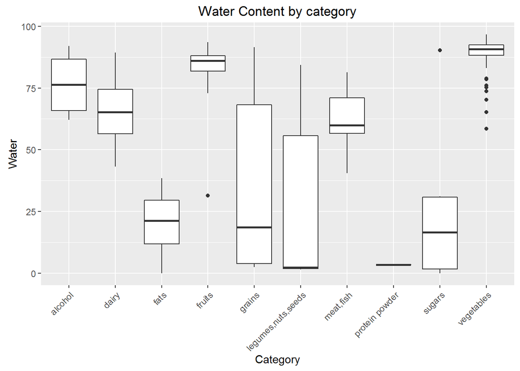

```r
g+geom_boxplot(aes(x=Category,y=Water))+ggtitle("Water Content by category")+ theme(legend.position="bottom", legend.direction="horizontal", axis.text.x = element_text(angle = 45, hjust=1))
```

Fruits and vegetables contain a higher content of water when we analyze foods by categories.

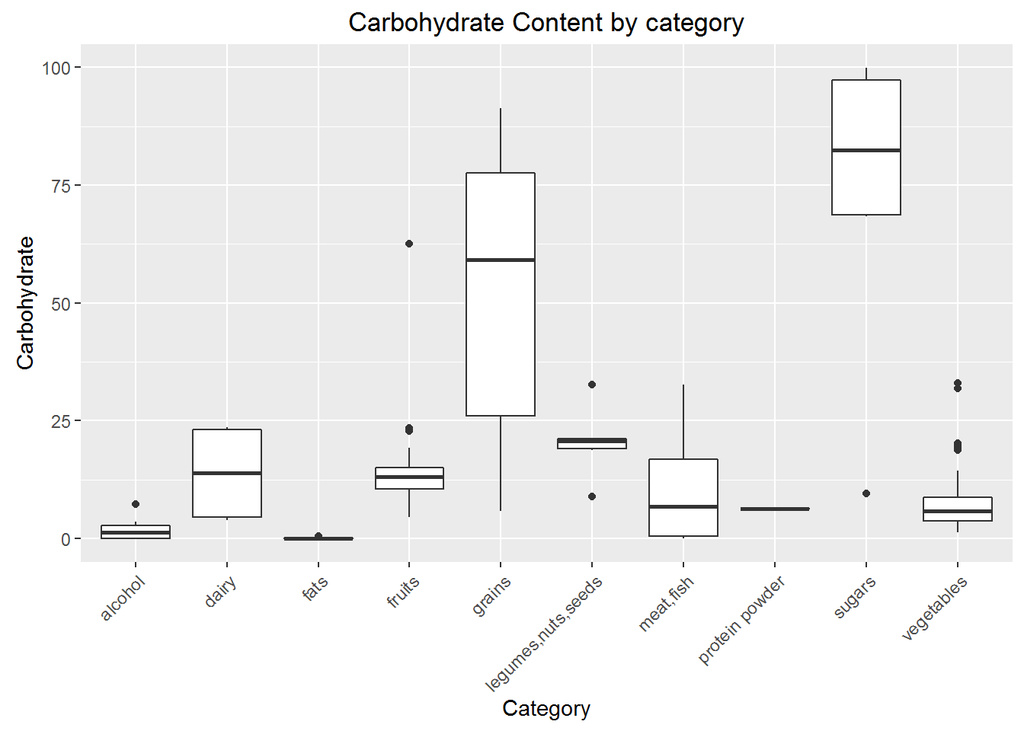

```r
g + geom_boxplot(aes(x=Category,y=Carbohydrate)) + ggtitle("Carbohydrate Content by category")+ theme(legend.position="bottom", legend.direction="horizontal", axis.text.x = element_text(angle = 45, hjust=1))
```

Sugars and grains contain the highest content of carbohydrate

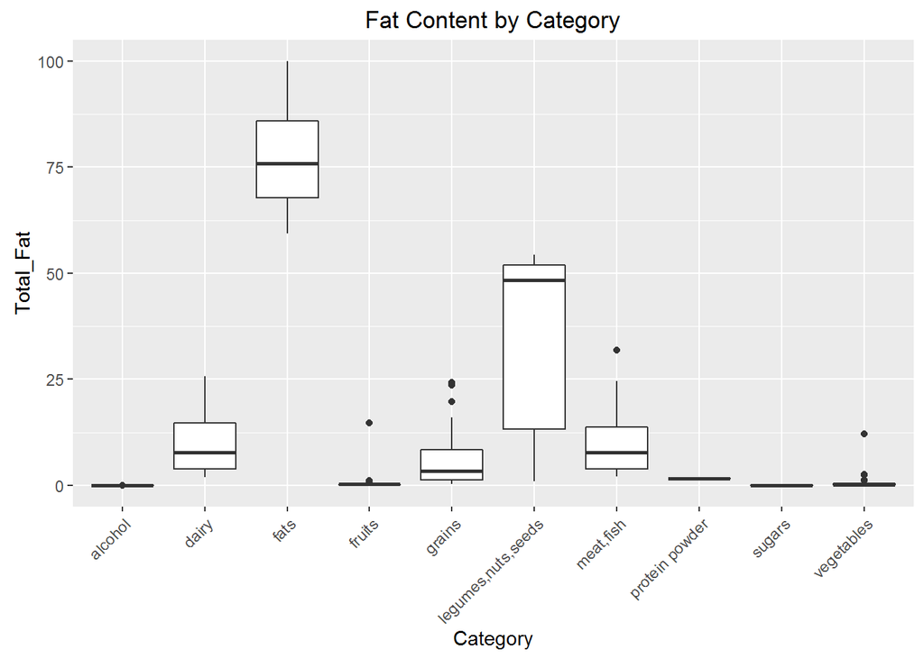

```r
g+geom_boxplot(aes(x=Category,y=Total_Fat))+ggtitle("Fat Content by Category")+ theme(legend.position="bottom", legend.direction="horizontal", axis.text.x = element_text(angle = 45, hjust=1))
```

Fats, legumes, nuts and seeds contain the highest concentration of fats

## Part-6: T-Tests

T-tests for “dairy”, “meat,fish”, “legumes,nuts,seeds”, “grains”, “fruits”, “vegetables”, “fats”, “sugars”, “alcohol” and “protein powder”

```r
#Obtaining subset of all food categories
Dairy_df<-sqldf("select * from data_final WHERE Category='dairy'")
Meat_df<-sqldf("select * from data_final WHERE Category='meat,fish'")
Legumes_df<-sqldf("select * from data_final WHERE Category='legumes,nuts,seeds'")
Grains_df<-sqldf("select * from data_final WHERE Category = 'grains'")
Fruits_df<-sqldf("select * from data_final WHERE Category ='fruits'")
Veggie_df<-sqldf("select * from data_final WHERE Category='vegetables'")
Fats_df<-sqldf("select * from data_final WHERE Category='fats'")
Sugar_df<-sqldf("select * from data_final WHERE Category='sugars'")
Alcohol_df<-sqldf("select * from data_final WHERE Category='alcohol'")
Prot_df<-sqldf("select * from data_final WHERE Category='protein powder'")
```

**Now, we can calculte the mean values of each nurtrient from our final dataset. This will give us an idea of what foodcategories+nutrients to apply T-tests on.**

```r
t_test_exp <- sqldf("SELECT  Category,
              avg(Calcium), avg(Carbohydrate),  avg(Energy),    avg(Iron),
              avg(Protein), avg(Total_Fat), avg(Total_Sugar),   avg(Potassium),
              avg(Phosphorus),  avg(Sodium),    avg(Vitamin_C), avg(Vitamin_B12),
              avg(Vitamin_D), avg(Water)
              FROM data_final
              GROUP BY Category
              ")
print(t_test_exp)
```

```
##              Category avg(Calcium) avg(Carbohydrate) avg(Energy) avg(Iron)
## 1             alcohol      3.00000          2.013750   157.25000 0.1275000
## 2               dairy    312.00000         13.820000   184.25000 0.5100000
## 3                fats     16.75000          0.155000   689.00000 0.0300000
## 4              fruits     23.40541         14.153784    59.86486 0.4032432
## 5              grains     65.64286         52.279286   284.78571 9.2978571
## 6  legumes,nuts,seeds     95.33333         20.471667   421.83333 3.0800000
## 7           meat,fish     53.62500          9.768750   203.87500 1.8225000
## 8      protein powder    469.00000          6.250000   352.00000 1.1300000
## 9              sugars     12.33333         73.493333   273.66667 0.1033333
## 10         vegetables     53.88679          7.864151    40.98113 1.0935849
##    avg(Protein) avg(Total_Fat) avg(Total_Sugar) avg(Potassium)
## 1      0.085000      0.0062500         0.957500       30.75000
## 2      7.897500     10.7975000        11.490000      168.00000
## 3      0.472500     77.7300000         0.022500       20.25000
```

[output cut: 29 more lines]

On the basis of the above results we have a little direction in which e can prform the t-tests

**CALCIUM** p-value = 0.6522: T-test for mean value of Calcium in Fats and Sugar shows that there is not enough evidence to reject the null hypothesis that the means are equal

```r
t.test(x = Fats_df$Calcium,y = Sugar_df$Calcium)
```

```
##
##  Welch Two Sample t-test
##
## data:  Fats_df$Calcium and Sugar_df$Calcium
## t = 0.4681, df = 7.986, p-value = 0.6522
## alternative hypothesis: true difference in means is not equal to 0
## 95 percent confidence interval:
##  -17.34570  26.17904
## sample estimates:
## mean of x mean of y
##  16.75000  12.33333
```

p-value = 0.9897: T-test for mean value of Calcium in Meat/fish and Vegetables shows that there is not enough evidence to reject the null hypothesis that the means are equal

```r
t.test(x = Veggie_df$Calcium,y = Meat_df$Calcium)
```

```
##
##  Welch Two Sample t-test
##
## data:  Veggie_df$Calcium and Meat_df$Calcium
## t = 0.013, df = 19.613, p-value = 0.9897
## alternative hypothesis: true difference in means is not equal to 0
## 95 percent confidence interval:
##  -41.69429  42.21787
## sample estimates:
## mean of x mean of y
##  53.88679  53.62500
```

**CARBOHYDRATE** p-value = 0.5256: T-test for mean value of Carbohydrate in Meat/fish and Vegetables shows that there is not enough evidence to reject the null hypothesis that the means are equal

```r
t.test(x = Veggie_df$Carbohydrate,y = Meat_df$Carbohydrate)
```

```
##
##  Welch Two Sample t-test
##
## data:  Veggie_df$Carbohydrate and Meat_df$Carbohydrate
## t = -0.647, df = 18.369, p-value = 0.5256
## alternative hypothesis: true difference in means is not equal to 0
## 95 percent confidence interval:
##  -8.079994  4.270796
## sample estimates:
## mean of x mean of y
##  7.864151  9.768750
```

p-value = 0.9564: T-test for mean value of Carbohydrate in fruits and dairy shows that there is not enough evidence to reject the null hypothesis that the means are equal

```r
t.test(x = Fruits_df$Carbohydrate,y = Dairy_df$Carbohydrate)
```

```
##
##  Welch Two Sample t-test
##
## data:  Fruits_df$Carbohydrate and Dairy_df$Carbohydrate
## t = 0.0587, df = 3.47, p-value = 0.9564
## alternative hypothesis: true difference in means is not equal to 0
## 95 percent confidence interval:
##  -16.44900  17.11656
## sample estimates:
## mean of x mean of y
##  14.15378  13.82000
```

**ENERGY** p-value = 0.01831: T-test for mean value of Energy in fruits and Vegetables shows that the mean of the two data sets is not the same

```r
t.test(x = Fruits_df$Energy,y = Veggie_df$Energy)
```

```
##
##  Welch Two Sample t-test
##
## data:  Fruits_df$Energy and Veggie_df$Energy
## t = 2.4178, df = 67.756, p-value = 0.01831
## alternative hypothesis: true difference in means is not equal to 0
## 95 percent confidence interval:
##   3.297527 34.469939
## sample estimates:
## mean of x mean of y
##  59.86486  40.98113
```

p-value = 0.8557: T-test for mean value of Energy in grains and sugars shows that there is not enough evidence to reject the null hypothesis that the means are equal

```r
t.test(x = Grains_df$Energy,y = Sugar_df$Energy)
```

```
##
##  Welch Two Sample t-test
##
## data:  Grains_df$Energy and Sugar_df$Energy
## t = 0.188, df = 7.704, p-value = 0.8557
## alternative hypothesis: true difference in means is not equal to 0
## 95 percent confidence interval:
##  -126.1522  148.3903
## sample estimates:
## mean of x mean of y
##  284.7857  273.6667
```

**IRON** p-value = 0.03503: T-test for mean value of Iron in meat,fish and Vegetables shows that the mean of the two data sets is not the same

```r
t.test(x = Meat_df$Iron,y = Veggie_df$Iron)
```

```
##
##  Welch Two Sample t-test
##
## data:  Meat_df$Iron and Veggie_df$Iron
## t = 2.2282, df = 25.184, p-value = 0.03503
## alternative hypothesis: true difference in means is not equal to 0
## 95 percent confidence interval:
##  0.05542215 1.40240804
## sample estimates:
## mean of x mean of y
##  1.822500  1.093585
```

p-value = 0.7429: T-test for mean value of Iron in fruits and dairy shows that there is not enough evidence to reject the null hypothesis that the means are equal

```r
t.test(x = Fruits_df$Iron,y = Dairy_df$Iron)
```

```
##
##  Welch Two Sample t-test
##
## data:  Fruits_df$Iron and Dairy_df$Iron
## t = -0.355, df = 3.502, p-value = 0.7429
## alternative hypothesis: true difference in means is not equal to 0
## 95 percent confidence interval:
##  -0.9906134  0.7770999
## sample estimates:
## mean of x mean of y
## 0.4032432 0.5100000
```

**PROTEIN** p-value = 0.7247: T-test for mean value of Protein in legumes,nuts,seeds and Meat/fish shows that there is not enough evidence to reject the null hypothesis that the means are equal

```r
t.test(x = Legumes_df$Protein,y = Meat_df$Protein)
```

```
##
##  Welch Two Sample t-test
##
## data:  Legumes_df$Protein and Meat_df$Protein
## t = -0.3627, df = 9.578, p-value = 0.7247
## alternative hypothesis: true difference in means is not equal to 0
## 95 percent confidence interval:
##  -11.101268   8.009184
## sample estimates:
## mean of x mean of y
##  14.69833  16.24437
```

p-value = 3.889e-06: T-test for mean value of Protein in Vegetables and Fruits shows that the mean of the tw data sets is not the same

```r
t.test(x = Veggie_df$Protein,y = Fruits_df$Protein)
```

```
##
##  Welch Two Sample t-test
##
## data:  Veggie_df$Protein and Fruits_df$Protein
## t = 4.9723, df = 77.37, p-value = 3.889e-06
## alternative hypothesis: true difference in means is not equal to 0
## 95 percent confidence interval:
##  0.6330703 1.4787196
## sample estimates:
## mean of x mean of y
##  2.058868  1.002973
```

**TOTAL FAT** p-value = 0.9721: T-test for mean value of Fat in Vegetables and Fruits shows that there is not enough evidence to reject the null hypothesis that the means are equal

```r
t.test(x = Veggie_df$Total_Fat,y = Fruits_df$Total_Fat)
```

```
##
##  Welch Two Sample t-test
##
## data:  Veggie_df$Total_Fat and Fruits_df$Total_Fat
## t = -0.0351, df = 60.883, p-value = 0.9721
## alternative hypothesis: true difference in means is not equal to 0
## 95 percent confidence interval:
##  -0.9235725  0.8917215
## sample estimates:
## mean of x mean of y
## 0.6924528 0.7083784
```

p-value = 0.9412: T-test for mean value of Fat in Meat/fish and Dairy shows that there is not enough evidence to reject the null hypothesis that the means are equal

```r
t.test(x = Dairy_df$Total_Fat,y = Meat_df$Total_Fat)
```

```
##
##  Welch Two Sample t-test
##
## data:  Dairy_df$Total_Fat and Meat_df$Total_Fat
## t = 0.0786, df = 3.98, p-value = 0.9412
## alternative hypothesis: true difference in means is not equal to 0
## 95 percent confidence interval:
##  -15.43767  16.33517
## sample estimates:
## mean of x mean of y
##  10.79750  10.34875
```

**TOTAL SUGAR** p-value = 9.143e-06: T-test for mean value of Sugar in Vegetables and Fruits shows that the mean of the two data sets is not the same

```r
t.test(x = Veggie_df$Total_Sugar,y = Fruits_df$Total_Sugar)
```

```
##
##  Welch Two Sample t-test
##
## data:  Veggie_df$Total_Sugar and Fruits_df$Total_Sugar
## t = -5.0762, df = 40.27, p-value = 9.143e-06
## alternative hypothesis: true difference in means is not equal to 0
## 95 percent confidence interval:
##  -10.48966  -4.51631
## sample estimates:
## mean of x mean of y
##  2.703774 10.206757
```

p-value = 0.6044: T-test for mean value of Sugar in Dairy and Grains shows that there is not enough evidence to reject the null hypothesis that the means are equal

```r
t.test(x = Dairy_df$Total_Sugar,y = Grains_df$Total_Sugar)
```

```
##
##  Welch Two Sample t-test
##
## data:  Dairy_df$Total_Sugar and Grains_df$Total_Sugar
## t = -0.5495, df = 5.465, p-value = 0.6044
## alternative hypothesis: true difference in means is not equal to 0
## 95 percent confidence interval:
##  -16.22900  10.39257
## sample estimates:
## mean of x mean of y
##  11.49000  14.40821
```

**POTASSIUM** p-value = 0.6882: T-test for mean value of Potassium in Grains and Fruits shows that there is not enough evidence to reject the null hypothesis that the means are equal

```r
t.test(x = Fruits_df$Potassium,y = Grains_df$Potassium)
```

```
##
##  Welch Two Sample t-test
##
## data:  Fruits_df$Potassium and Grains_df$Potassium
## t = 0.404, df = 42.909, p-value = 0.6882
## alternative hypothesis: true difference in means is not equal to 0
## 95 percent confidence interval:
##  -64.64232  97.02649
## sample estimates:
## mean of x mean of y
##  209.5135  193.3214
```

**PHOSPHORUS** p-value = 0.2271: T-test for mean value of Phosphorus in Fats and Fruits shows that there is not enough evidence to reject the null hypothesis that the means are equal

```r
t.test(x = Fruits_df$Phosphorus,y = Fats_df$Phosphorus)
```

```
##
##  Welch Two Sample t-test
##
## data:  Fruits_df$Phosphorus and Fats_df$Phosphorus
## t = 1.3505, df = 5.804, p-value = 0.2271
## alternative hypothesis: true difference in means is not equal to 0
## 95 percent confidence interval:
##  -6.949691 23.760502
## sample estimates:
## mean of x mean of y
##  23.40541  15.00000
```

**SODIUM** p-value = 0.797: T-test for mean value of Sodium in Grains and legumes,nuts,seeds shows that there is not enough evidence to reject the null hypothesis that the means are equal

```r
t.test(x = Grains_df$Sodium,y = Legumes_df$Sodium)
```

```
##
##  Welch Two Sample t-test
##
## data:  Grains_df$Sodium and Legumes_df$Sodium
## t = -0.2634, df = 11.244, p-value = 0.797
## alternative hypothesis: true difference in means is not equal to 0
## 95 percent confidence interval:
##  -184.7758  145.1805
## sample estimates:
## mean of x mean of y
##  420.0357  439.8333
```

**VITAMIN C** p-value = 0.4535: T-test for mean value of Vitamin C in Alcohol and Dairy shows that there is not enough evidence to reject the null hypothesis that the means are equal

```r
t.test(x = Alcohol_df$Vitamin_C,y = Dairy_df$Vitamin_C)
```

```
##
##  Welch Two Sample t-test
##
## data:  Alcohol_df$Vitamin_C and Dairy_df$Vitamin_C
## t = -0.7918, df = 7.277, p-value = 0.4535
## alternative hypothesis: true difference in means is not equal to 0
## 95 percent confidence interval:
##  -0.5449809  0.2699809
## sample estimates:
## mean of x mean of y
##    0.1125    0.2500
```

**VITAMIN B12** p-value = 0.3046: T-test for mean value of Vitamin B12 in legumes,nuts,seeds and Vegetables shows that there is not enough evidence to reject the null hypothesis that the means are equal

```r
t.test(x = Legumes_df$Vitamin_B12,y = Veggie_df$Vitamin_B12)
```

```
##
##  Welch Two Sample t-test
##
## data:  Legumes_df$Vitamin_B12 and Veggie_df$Vitamin_B12
## t = -1.036, df = 56.531, p-value = 0.3046
## alternative hypothesis: true difference in means is not equal to 0
## 95 percent confidence interval:
##  -0.030069468  0.009566324
## sample estimates:
##   mean of x   mean of y
## 0.003333333 0.013584906
```

**VITAMIN D** p-value = 0.95: T-test for mean value of Vitamin D in Fats and Grains shows that there is not enough evidence to reject the null hypothesis that the means are equal

```r
t.test(x = Fats_df$Vitamin_D,y = Grains_df$Vitamin_D)
```

```
##
##  Welch Two Sample t-test
##
## data:  Fats_df$Vitamin_D and Grains_df$Vitamin_D
## t = 0.0648, df = 7.968, p-value = 0.95
## alternative hypothesis: true difference in means is not equal to 0
## 95 percent confidence interval:
##  -1.113111  1.177397
## sample estimates:
## mean of x mean of y
##  1.150000  1.117857
```

p-value = 0.5727: T-test for mean value of Vitamin D in Fruits and Vegetables shows that there is not enough evidence to reject the null hypothesis that the means are equal

```r
t.test(x = Fruits_df$Vitamin_D,y = Veggie_df$Vitamin_D)
```

```
##
##  Welch Two Sample t-test
##
## data:  Fruits_df$Vitamin_D and Veggie_df$Vitamin_D
## t = -0.5664, df = 82.387, p-value = 0.5727
## alternative hypothesis: true difference in means is not equal to 0
## 95 percent confidence interval:
##  -0.03635399  0.02023977
## sample estimates:
##  mean of x  mean of y
## 0.01081081 0.01886792
```

**WATER** p-value = 0.6948: T-test for mean value of Water in Meat,fish and Dairy shows that there is not enough evidence to reject the null hypothesis that the means are equal

```r
t.test(x = Meat_df$Water,y = Dairy_df$Water)
```

```
##
##  Welch Two Sample t-test
##
## data:  Meat_df$Water and Dairy_df$Water
## t = -0.4245, df = 3.678, p-value = 0.6948
## alternative hypothesis: true difference in means is not equal to 0
## 95 percent confidence interval:
##  -33.23719  24.68469
## sample estimates:
## mean of x mean of y
##  61.44375  65.72000
```

p-value = 0.6976: T-test for mean value of Water in Fats and legumes,nuts,seeds shows that there is not enough evidence to reject the null hypothesis that the means are equal

```r
t.test(x = Fats_df$Water,y = Legumes_df$Water)
```

```
##
##  Welch Two Sample t-test
##
## data:  Fats_df$Water and Legumes_df$Water
## t = -0.4048, df = 7.087, p-value = 0.6976
## alternative hypothesis: true difference in means is not equal to 0
## 95 percent confidence interval:
##  -50.33491  35.58991
## sample estimates:
## mean of x mean of y
##   20.2525   27.6250
```

## Part-7: CORRELATIONS Between Nutrients

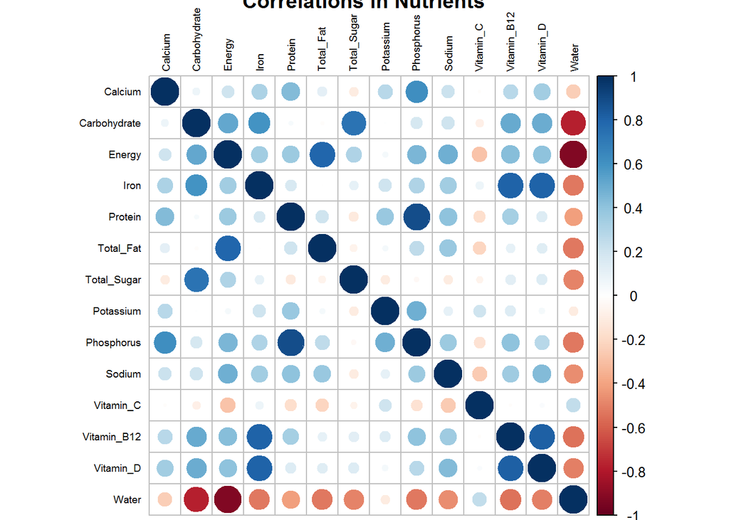

```r
#scaling data because everything is in different units
dat <- scale(data_final[-ncol(data_final)])

par(mfrow= c(1,1))
corrplot::corrplot(cor(dat,
                       method = c("pearson", "kendall", "spearman")), tl.cex=0.6, tl.col = "black", title = "Correlations in Nutrients")
```

```r
correlations <- cor(dat, use="pairwise")
print(correlations)
```

```
##                  Calcium Carbohydrate      Energy         Iron     Protein
## Calcium       1.00000000  0.075518870  0.20058601  0.317048087  0.43590083
## Carbohydrate  0.07551887  1.000000000  0.51085386  0.596111306  0.03093308
## Energy        0.20058601  0.510853861  1.00000000  0.345691180  0.36602312
## Iron          0.31704809  0.596111306  0.34569118  1.000000000  0.16916440
## Protein       0.43590083  0.030933081  0.36602312  0.169164404  1.00000000
## Total_Fat     0.11784949 -0.018437621  0.79568321 -0.003248849  0.20722571
## Total_Sugar  -0.10550005  0.731503892  0.30539899  0.104753367 -0.11729602
## Potassium     0.27305442  0.004893782  0.04132377  0.208248455  0.37121817
## Phosphorus    0.61893587  0.177932090  0.45499617  0.307117671  0.88170462
## Sodium        0.21975846  0.207926923  0.48517677  0.342158416  0.40375388
## Vitamin_C    -0.01475123 -0.080815185 -0.28883818  0.078775646 -0.17333280
## Vitamin_B12   0.27510027  0.505969002  0.42063126  0.801412434  0.33760181
## Vitamin_D     0.34233113  0.498324088  0.40471352  0.808353910  0.14249361
## Water        -0.24256773 -0.775117814 -0.92081213 -0.520296919 -0.41218963
##                 Total_Fat Total_Sugar    Potassium  Phosphorus     Sodium
## Calcium       0.117849486 -0.10550005  0.273054423  0.61893587  0.2197585
## Carbohydrate -0.018437621  0.73150389  0.004893782  0.17793209  0.2079269
## Energy        0.795683207  0.30539899  0.041323774  0.45499617  0.4851768
## Iron         -0.003248849  0.10475337  0.208248455  0.30711767  0.3421584
## Protein       0.207225711 -0.11729602  0.371218167  0.88170462  0.4037539
## Total_Fat     1.000000000 -0.06717576  0.048055546  0.25897573  0.3761721
## Total_Sugar  -0.067175758  1.00000000 -0.102804695 -0.03421439 -0.1030471
## Potassium     0.048055546 -0.10280470  1.000000000  0.48336160  0.1067280
## Phosphorus    0.258975730 -0.03421439  0.483361596  1.00000000  0.3608507
## Sodium        0.376172138 -0.10304709  0.106727981  0.36085070  1.0000000
## Vitamin_C    -0.219957642 -0.06478296  0.201757791 -0.15731687 -0.2590123
## Vitamin_B12   0.106630507  0.12869608  0.149373444  0.40056739  0.3543311
## Vitamin_D     0.137869967  0.14994031  0.049781857  0.27408741  0.4302050
## Water        -0.522431728 -0.49152823 -0.103978515 -0.52330352 -0.4624494
##                Vitamin_C Vitamin_B12   Vitamin_D      Water
## Calcium      -0.01475123  0.27510027  0.34233113 -0.2425677
## Carbohydrate -0.08081518  0.50596900  0.49832409 -0.7751178
## Energy       -0.28883818  0.42063126  0.40471352 -0.9208121
## Iron          0.07877565  0.80141243  0.80835391 -0.5202969
## Protein      -0.17333280  0.33760181  0.14249361 -0.4121896
## Total_Fat    -0.21995764  0.10663051  0.13786997 -0.5224317
## Total_Sugar  -0.06478296  0.12869608  0.14994031 -0.4915282
## Potassium     0.20175779  0.14937344  0.04978186 -0.1039785
## Phosphorus   -0.15731687  0.40056739  0.27408741 -0.5233035
## Sodium       -0.25901227  0.35433105  0.43020500 -0.4624494
## Vitamin_C     1.00000000 -0.01161722  0.02938613  0.2441998
## Vitamin_B12  -0.01161722  1.00000000  0.81392479 -0.5496231
## Vitamin_D     0.02938613  0.81392479  1.00000000 -0.5044188
## Water         0.24419977 -0.54962308 -0.50441884  1.0000000
```

1. This shows that Energy and Total Fat are highly likely to be found together- correlation 0.79
2. It is highly unlikely that Protein and Carbohydrate will be found together in any food- correlation 0.03
3. It is highly unlikely that Total Fat and Potassium will be found together in any food- correlation 0.04
4. This shows that Sugar and Carbohydrate are highly likely to be found together- correlation 0.73
5. This shows that Vitamin D and Vitamin B12 are highly likely to be found together- correlation 0.81
6. This shows that Vitamin C and Energy are will almolst never be found together- correlation -0.28
7. This shows that Water and Energy are will almolst never be found together- correlation -0.92
8. This shows that Water and Carbohydrate are will almolst never be found together- correlation -0.77
9. This shows that Iron and Vitamin B12 are highly likely to be found together- correlation 0.80
10. This shows that Phosphorus and Protein are highly likely to be found together- correlation 0.88

**Now, that we have analyzed the dataset as a whole; let us also analyze the correlations within different food categories**

**VEGETABLES**

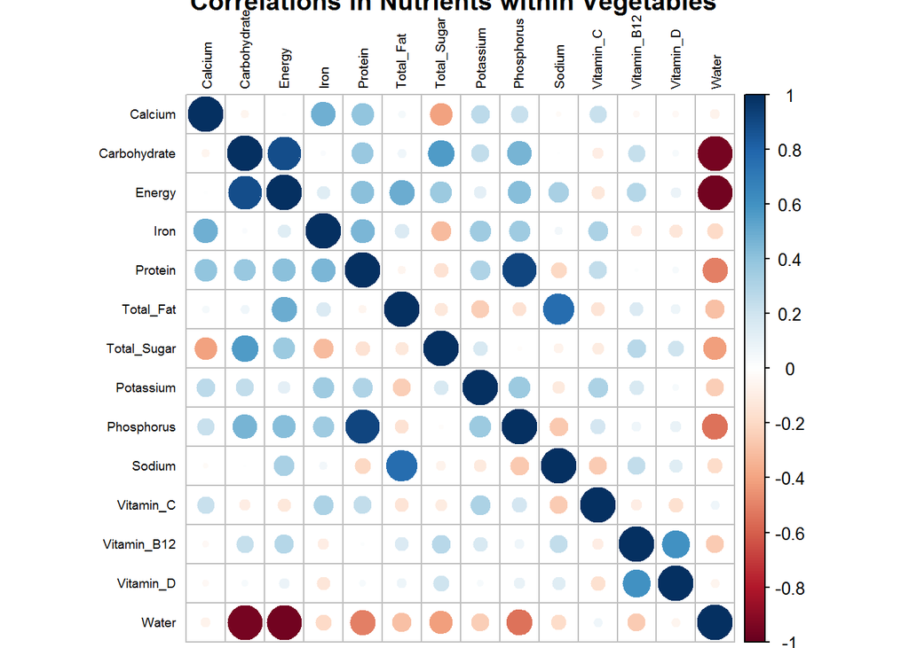

```r
dat_veg <- scale(Veggie_df[-ncol(Veggie_df)])

corrplot::corrplot(cor(dat_veg), tl.cex=0.6, tl.col = "black", title = "Correlations in Nutrients within Vegetables")
```

```r
correlations_vegetables <- cor(dat_veg, use="pairwise")
print(correlations_vegetables)
```

```
##                   Calcium Carbohydrate       Energy        Iron
## Calcium       1.000000000 -0.055982251  0.007692211  0.48302942
## Carbohydrate -0.055982251  1.000000000  0.886335104  0.02518235
## Energy        0.007692211  0.886335104  1.000000000  0.13939236
## Iron          0.483029417  0.025182354  0.139392356  1.00000000
## Protein       0.394072885  0.377180235  0.413250476  0.45956802
## Total_Fat     0.043888604  0.064787456  0.495190270  0.15960666
## Total_Sugar  -0.401436601  0.564910960  0.365484097 -0.31266463
## Potassium     0.264000709  0.241298199  0.112935852  0.35314724
## Phosphorus    0.228442332  0.465695121  0.429737116  0.35832893
## Sodium       -0.023701894  0.005444457  0.328763483  0.05731795
## Vitamin_C     0.223835763 -0.090531398 -0.126318953  0.31795651
## Vitamin_B12  -0.033945775  0.231361402  0.280108424 -0.09889270
## Vitamin_D    -0.038836717  0.036573003  0.086968647 -0.13777277
## Water        -0.068697035 -0.950938081 -0.968484361 -0.19294637
##                  Protein   Total_Fat Total_Sugar   Potassium  Phosphorus
## Calcium       0.39407288  0.04388860 -0.40143660  0.26400071  0.22844233
## Carbohydrate  0.37718024  0.06478746  0.56491096  0.24129820  0.46569512
## Energy        0.41325048  0.49519027  0.36548410  0.11293585  0.42973712
## Iron          0.45956802  0.15960666 -0.31266463  0.35314724  0.35832893
## Protein       1.00000000 -0.05614428 -0.15644019  0.30576927  0.91900125
## Total_Fat    -0.05614428  1.00000000 -0.12971778 -0.24476890 -0.15197882
## Total_Sugar  -0.15644019 -0.12971778  1.00000000  0.16841250 -0.01955557
## Potassium     0.30576927 -0.24476890  0.16841250  1.00000000  0.36886458
## Phosphorus    0.91900125 -0.15197882 -0.01955557  0.36886458  1.00000000
## Sodium       -0.20199781  0.76920425 -0.06743574 -0.11636236 -0.26457933
## Vitamin_C     0.24121473 -0.14603557 -0.10979834  0.31896804  0.18085991
## Vitamin_B12   0.01237166  0.15060073  0.27376296  0.16260487  0.06976639
## Vitamin_D     0.03851720  0.07633462  0.20059704  0.03970085  0.09895500
## Water        -0.50704216 -0.29841692 -0.41596230 -0.24019612 -0.54434746
##                    Sodium   Vitamin_C Vitamin_B12   Vitamin_D       Water
## Calcium      -0.023701894  0.22383576 -0.03394578 -0.03883672 -0.06869703
## Carbohydrate  0.005444457 -0.09053140  0.23136140  0.03657300 -0.95093808
## Energy        0.328763483 -0.12631895  0.28010842  0.08696865 -0.96848436
## Iron          0.057317954  0.31795651 -0.09889270 -0.13777277 -0.19294637
## Protein      -0.201997809  0.24121473  0.01237166  0.03851720 -0.50704216
## Total_Fat     0.769204247 -0.14603557  0.15060073  0.07633462 -0.29841692
## Total_Sugar  -0.067435740 -0.10979834  0.27376296  0.20059704 -0.41596230
## Potassium    -0.116362365  0.31896804  0.16260487  0.03970085 -0.24019612
## Phosphorus   -0.264579329  0.18085991  0.06976639  0.09895500 -0.54434746
## Sodium        1.000000000 -0.25585312  0.24035360  0.13757053 -0.18595014
## Vitamin_C    -0.255853125  1.00000000 -0.09913012 -0.16051970  0.06459408
## Vitamin_B12   0.240353599 -0.09913012  1.00000000  0.60501084 -0.25071298
## Vitamin_D     0.137570532 -0.16051970  0.60501084  1.00000000 -0.05951485
## Water        -0.185950144  0.06459408 -0.25071298 -0.05951485  1.00000000
```

1. It can be seen that Phosphorus and Protein are highly likely to be present together in vegetables
2. Sodium and Total Fat are highly likely to be present together in vegetables
3. It can also be seen that Phosphorus and Water are unlikely to be present together in vegetables
4. Similarly, sugar and Calcium are also unlikely to be seen together in vegetables

**Please note that broadly, nutrient correlations still show similar correlations as in the bigger dataset.**

**DAIRY**

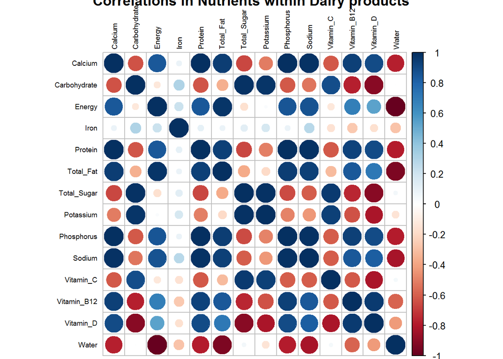

```r
dat_dairy <- scale(Dairy_df[-ncol(Dairy_df)])

corrplot::corrplot(cor(dat_dairy),
                        tl.cex=0.6, tl.col = "black", title = "Correlations in Nutrients within Dairy products")
```

```r
correlations_dairy <- cor(dat_dairy , use="pairwise")
print(correlations_dairy)
```

```
##                  Calcium Carbohydrate     Energy        Iron    Protein
## Calcium       1.00000000 -0.630369829  0.8443020  0.08220611  0.9998335
## Carbohydrate -0.63036983  1.000000000 -0.1253454  0.30391298 -0.6239594
## Energy        0.84430203 -0.125345410  1.0000000  0.21085532  0.8465958
## Iron          0.08220611  0.303912981  0.2108553  1.00000000  0.1003759
## Protein       0.99983350 -0.623959352  0.8465958  0.10037594  1.0000000
## Total_Fat     0.94001511 -0.354937971  0.9708884  0.08426422  0.9398841
## Total_Sugar  -0.66684632  0.984007271 -0.1637535  0.12945860 -0.6635784
## Potassium    -0.51138345  0.973919232  0.0287270  0.17930915 -0.5074953
## Phosphorus    0.99990280 -0.619595390  0.8516743  0.08676731  0.9998160
## Sodium        0.98020209 -0.531411595  0.8677129  0.27649422  0.9836184
## Vitamin_C    -0.61411543  0.888107303 -0.1295709 -0.15680359 -0.6161944
## Vitamin_B12   0.93300984 -0.778451662  0.6886383 -0.26877656  0.9265588
## Vitamin_D     0.89676280 -0.906847832  0.5318034 -0.16971680  0.8922676
## Water        -0.77711005  0.004202727 -0.9916686 -0.28988116 -0.7809418
##                Total_Fat Total_Sugar  Potassium  Phosphorus     Sodium
## Calcium       0.94001511 -0.66684632 -0.5113835  0.99990280  0.9802021
## Carbohydrate -0.35493797  0.98400727  0.9739192 -0.61959539 -0.5314116
## Energy        0.97088843 -0.16375353  0.0287270  0.85167431  0.8677129
## Iron          0.08426422  0.12945860  0.1793091  0.08676731  0.2764942
## Protein       0.93988415 -0.66357842 -0.5074953  0.99981601  0.9836184
## Total_Fat     1.00000000 -0.37934020 -0.1960171  0.94444655  0.9308528
## Total_Sugar  -0.37934020  1.00000000  0.9813632 -0.65642884 -0.6002158
## Potassium    -0.19601706  0.98136324  1.0000000 -0.49938506 -0.4379572
## Phosphorus    0.94444655 -0.65642884 -0.4993851  1.00000000  0.9813196
## Sodium        0.93085284 -0.60021582 -0.4379572  0.98131960  1.0000000
## Vitamin_C    -0.31132573  0.95429424  0.9395140 -0.60424883 -0.6044272
## Vitamin_B12   0.84167366 -0.75598886 -0.6342905  0.93005827  0.8441086
## Vitamin_D     0.71541029 -0.90953710 -0.8191579  0.89069741  0.8222611
## Water        -0.93231961  0.05246657 -0.1403414 -0.78580425 -0.8201932
##                Vitamin_C Vitamin_B12  Vitamin_D        Water
## Calcium      -0.61411543   0.9330098  0.8967628 -0.777110048
## Carbohydrate  0.88810730  -0.7784517 -0.9068478  0.004202727
## Energy       -0.12957088   0.6886383  0.5318034 -0.991668594
## Iron         -0.15680359  -0.2687766 -0.1697168 -0.289881164
## Protein      -0.61619438   0.9265588  0.8922676 -0.780941786
## Total_Fat    -0.31132573   0.8416737  0.7154103 -0.932319611
## Total_Sugar   0.95429424  -0.7559889 -0.9095371  0.052466573
## Potassium     0.93951401  -0.6342905 -0.8191579 -0.140341431
## Phosphorus   -0.60424883   0.9300583  0.8906974 -0.785804247
## Sodium       -0.60442722   0.8441086  0.8222611 -0.820193210
## Vitamin_C     1.00000000  -0.6115157 -0.8131963  0.042336529
## Vitamin_B12  -0.61151569   1.0000000  0.9569978 -0.589743628
## Vitamin_D    -0.81319629   0.9569978  1.0000000 -0.424863000
## Water         0.04233653  -0.5897436 -0.4248630  1.000000000
```

Dairy products show an extreme behaviour. Either they are highly correlated to nutrients or they show strict negative correlations. 1. It can be seen that Energy and Fat are highly likely to be present together in dairy- correlation 0.97 2. Vitamin B12 and Vitamin D are highly likely to be present together in dairy- correlation 0.95 3. It can also be seen that Vitamin D and Carbohydrate are unlikely to be present together in dairy- correlation -.90 4. Similarly, Water and Enerygy are also unlikely to be seen together in dairy- correlation -0.99

**Meat,Fish**

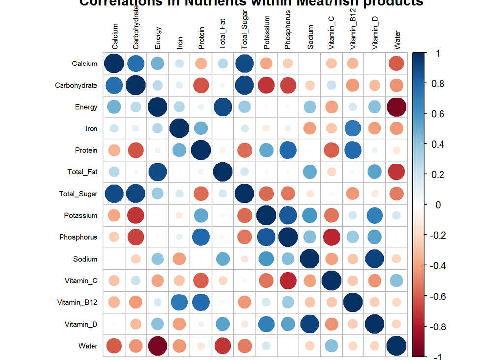

```r
dat_meat <- scale(Meat_df[-ncol(Meat_df)])

corrplot::corrplot(cor(dat_meat), tl.cex=0.6, tl.col = "black", title = "Correlations in Nutrients within Meat/fish products")
```

```r
correlations_meat <- cor(dat_meat, use = "pairwise")
print(correlations_meat)
```

```
##                   Calcium Carbohydrate      Energy        Iron     Protein
## Calcium       1.000000000   0.75178383  0.47512303  0.19406505 -0.34895506
## Carbohydrate  0.751783828   1.00000000  0.26523873  0.11860798 -0.62506951
## Energy        0.475123034   0.26523873  1.00000000  0.28982458  0.08695275
## Iron          0.194065053   0.11860798  0.28982458  1.00000000  0.48003927
## Protein      -0.348955057  -0.62506951  0.08695275  0.48003927  1.00000000
## Total_Fat     0.271854262   0.05010363  0.89760272  0.02250628 -0.07159703
## Total_Sugar   0.899783747   0.91187330  0.36506056  0.16528836 -0.55509429
## Potassium    -0.387670180  -0.71746581 -0.02690161 -0.11479130  0.51142360
## Phosphorus   -0.241302013  -0.67288263  0.03641835  0.09728023  0.78058291
## Sodium        0.001583066  -0.22721457  0.39797432 -0.41955989 -0.01300789
## Vitamin_C    -0.289016492   0.21914615 -0.39332108 -0.27884705 -0.59869591
## Vitamin_B12  -0.324400148  -0.42201202  0.16944882  0.71892975  0.77709176
## Vitamin_D     0.016662759  -0.31749494  0.41536812 -0.41634732  0.08144145
## Water        -0.601480567  -0.44941748 -0.94519028 -0.43840033 -0.12663664
##                Total_Fat Total_Sugar   Potassium  Phosphorus       Sodium
## Calcium       0.27185426  0.89978375 -0.38767018 -0.24130201  0.001583066
## Carbohydrate  0.05010363  0.91187330 -0.71746581 -0.67288263 -0.227214570
## Energy        0.89760272  0.36506056 -0.02690161  0.03641835  0.397974323
## Iron          0.02250628  0.16528836 -0.11479130  0.09728023 -0.419559892
## Protein      -0.07159703 -0.55509429  0.51142360  0.78058291 -0.013007890
## Total_Fat     1.00000000  0.17399306  0.04620097 -0.03080886  0.506555413
## Total_Sugar   0.17399306  1.00000000 -0.56257728 -0.52892510 -0.139550661
## Potassium     0.04620097 -0.56257728  1.00000000  0.84483859  0.587598438
## Phosphorus   -0.03080886 -0.52892510  0.84483859  1.00000000  0.422114678
## Sodium        0.50655541 -0.13955066  0.58759844  0.42211468  1.000000000
## Vitamin_C    -0.20179107  0.04186152 -0.53845736 -0.75599779 -0.404834393
## Vitamin_B12   0.04606127 -0.43279313  0.17212802  0.36792638 -0.274957295
## Vitamin_D     0.53534587 -0.12680926  0.68447728  0.53630404  0.920568958
## Water        -0.71450921 -0.51349496  0.17855845  0.01168119 -0.219233082
##                Vitamin_C Vitamin_B12   Vitamin_D       Water
## Calcium      -0.28901649 -0.32440015  0.01666276 -0.60148057
## Carbohydrate  0.21914615 -0.42201202 -0.31749494 -0.44941748
## Energy       -0.39332108  0.16944882  0.41536812 -0.94519028
## Iron         -0.27884705  0.71892975 -0.41634732 -0.43840033
## Protein      -0.59869591  0.77709176  0.08144145 -0.12663664
## Total_Fat    -0.20179107  0.04606127  0.53534587 -0.71450921
## Total_Sugar   0.04186152 -0.43279313 -0.12680926 -0.51349496
## Potassium    -0.53845736  0.17212802  0.68447728  0.17855845
## Phosphorus   -0.75599779  0.36792638  0.53630404  0.01168119
## Sodium       -0.40483439 -0.27495729  0.92056896 -0.21923308
## Vitamin_C     1.00000000 -0.26112558 -0.44512458  0.41966972
## Vitamin_B12  -0.26112558  1.00000000 -0.24758618 -0.20205773
## Vitamin_D    -0.44512458 -0.24758618  1.00000000 -0.21924125
## Water         0.41966972 -0.20205773 -0.21924125  1.00000000
```

Meat,fish products show an behaviour similar to the original correlations of the entire data set. 1. It can be seen that Potassium and Phosphorus are highly likely to be present together in Meat,Fish- correlation 0.84 2. Vitamin B12 and Protein are highly likely to be present together in Meat,Fish- correlation 0.77 3. It can also be seen that Potassium and Carbohydrate are unlikely to be present together in Meat,Fish- correlation -0.71 4. Similarly, Carbohydrate and Protein are also unlikely to be seen together in Meat,Fish- correlation -.62

## Part-8: Support Vector Machines

```r
veg_fruit_df <- sqldf("SELECT * FROM data_final
                      WHERE Category IN ('vegetables', 'fruits')")
count_veg_fruits <- sqldf("SELECT Category, COUNT(*) Frequency
                          FROM veg_fruit_df
                          GROUP BY category
                          ORDER BY frequency DESC")
print(count_veg_fruits)
```

```
##     Category Frequency
## 1 vegetables        53
## 2     fruits        37
```

Splitting the data into features and labels

```r
data_x<-as.matrix(veg_fruit_df[-ncol(veg_fruit_df)])
data_y<-as.matrix(veg_fruit_df[ncol(veg_fruit_df)])
observations <- nrow(data_y)
print("Number of data observations in Fruits and Vegetables data frame are:")
```

```
## [1] "Number of data observations in Fruits and Vegetables data frame are:"
```

```r
print(observations)
```

```
## [1] 90
```

data_x is a vector of numeric values data_y is a vector of labels containing the classification of the corresponding xvalue

```r
ntrain <- round(observations*0.75) # number of training examples
tindex <- sample(ntrain, size=observations, replace=TRUE) # indices of training samples '
xtrain <- data_x[tindex,]
xtest <- data_x[-tindex,]
ytrain <- data_y[tindex,]
ytest <- data_y[-tindex,]
istrain <- rep(0,observations)
istrain[tindex] <- 1
```

Applying Linear Support Vector Machines classification on the data to train the SVC model. Taking the cost function as 100

```r
library(kernlab)
svp <- ksvm(x = xtrain, y = ytrain, type = "C-svc", kernel = 'vanilladot', C = 100, scaled = c())
```

Now that the SVM model has been trained. We will evaluate the prediction of the model

```r
ypred <- predict(svp, xtest)
confusion_matrix<- table(ytest,ypred)
accuracy <- sum(ypred==ytest)/length(ytest)

print("Confusion Matrix:")
```

```
## [1] "Confusion Matrix:"
```

```r
print(confusion_matrix)
```

```
##             ypred
## ytest        fruits vegetables
##   fruits          9          1
##   vegetables     17         14
```

```r
print(sprintf("Accuracy of the SVM model is: %s percent",accuracy*100))
```

```
## [1] "Accuracy of the SVM model is: 56.0975609756098 percent"
```

## Part-8: Logistic Regression only for Classification

Binomial Logistic Regression requires that the data labels are 0s and 1s Changing labels for fruits to 0s and Vegetables to 1s. Consequently, fitting a null model and generating it’s summary for model evaluation. If Null Deviance is really small, it means that the Null Model explains the data pretty well.

The residual deviance shows how well the response is predicted by the model when the predictors are included. For example, If the deviance goes up by 3443.3 when 22 predictor variables are added (note: degrees of freedom = no. of observations - no. of predictors). This increase in deviance is evidence of a significant lack of fit.

Also, note that logistic regression does not require the data to be normalized.

```r
Data_LRM <- veg_fruit_df
Data_LRM$Category <- ifelse(Data_LRM$Category=="fruits", 0, 1)
Data_LRM$Category <- as.factor(Data_LRM$Category)
fit.null <- glm(Category ~ 1, family=binomial(link="logit"), data=Data_LRM)
print(summary(fit.null))
```

```
##
## Call:
## glm(formula = Category ~ 1, family = binomial(link = "logit"),
##     data = Data_LRM)
##
## Deviance Residuals:
##    Min      1Q  Median      3Q     Max
## -1.333  -1.333   1.029   1.029   1.029
##
## Coefficients:
##             Estimate Std. Error z value Pr(>|z|)
## (Intercept)   0.3594     0.2142   1.678   0.0934 .
## ---
## Signif. codes:  0 '***' 0.001 '**' 0.01 '*' 0.05 '.' 0.1 ' ' 1
##
## (Dispersion parameter for binomial family taken to be 1)
##
##     Null deviance: 121.91  on 89  degrees of freedom
## Residual deviance: 121.91  on 89  degrees of freedom
## AIC: 123.91
##
## Number of Fisher Scoring iterations: 4
```

The summary shows Null deviance of 121.91 on 89 degrees of freedom & Residual deviance of 121.91 on 89 degrees of freedom. The degree of freedom has not reduced because this is a null model. The AIC score of 123.91 will be used to analyze the full model.

Now, fitting a full model to the logistic regression data and calling its summary to evaluate the full model

```r
fit.full <- glm(Category~., family=binomial(link="logit"), data=Data_LRM)
print(summary(fit.full))
```

```
##
## Call:
## glm(formula = Category ~ ., family = binomial(link = "logit"),
##     data = Data_LRM)
##
## Deviance Residuals:
##        Min          1Q      Median          3Q         Max
## -9.843e-05  -2.100e-08   2.100e-08   2.100e-08   9.163e-05
##
## Coefficients:
##                Estimate Std. Error z value Pr(>|z|)
## (Intercept)   7.167e+04  1.708e+07   0.004    0.997
## Calcium      -3.313e+00  6.628e+02  -0.005    0.996
## Carbohydrate -7.567e+02  1.796e+05  -0.004    0.997
## Energy        1.617e+01  4.683e+03   0.003    0.997
## Iron          1.042e+01  4.499e+04   0.000    1.000
## Protein      -7.255e+02  2.020e+05  -0.004    0.997
## Total_Fat    -1.066e+03  2.222e+05  -0.005    0.996
## Total_Sugar  -4.614e+01  1.130e+04  -0.004    0.997
## Potassium    -1.544e+00  3.908e+02  -0.004    0.997
## Phosphorus    3.421e-01  4.865e+02   0.001    0.999
## Sodium        5.248e-01  6.278e+02   0.001    0.999
## Vitamin_C    -9.046e-01  2.409e+02  -0.004    0.997
## Vitamin_B12  -1.610e+03  1.564e+06  -0.001    0.999
## Vitamin_D     2.150e+02  5.474e+05   0.000    1.000
## Water        -7.152e+02  1.705e+05  -0.004    0.997
##
## (Dispersion parameter for binomial family taken to be 1)
##
##     Null deviance: 1.2191e+02  on 89  degrees of freedom
## Residual deviance: 6.2246e-08  on 75  degrees of freedom
## AIC: 30
##
## Number of Fisher Scoring iterations: 25
```

This full model gives a Null deviance of 1.2191e+02 on 89 degrees of freedom and Residual deviance of 6.2246e-08 on 75 degrees of freedom. This shows a significant improvement in the model fit. AIC of 30 shows there is very little information loss in this model. But, this model is too complicated.

We will now use the step function to assess the models between a null and a full model which one is the best fit for the data, such that we have the lowest AIC scores for certain degree of freedom

```r
fit.step <- step(fit.null,
                 scope=list(lower=fit.null, upper=fit.full), direction=  "both")
```

```
## Start:  AIC=123.91
## Category ~ 1
```

```
##                Df Deviance     AIC
## + Total_Sugar   1   64.904  68.904
## + Sodium        1   76.933  80.933
## + Protein       1   97.899 101.899
## + Phosphorus    1  100.389 104.389
## + Carbohydrate  1  105.814 109.814
## + Iron          1  106.401 110.401
## + Calcium       1  108.406 112.406
## + Potassium     1  111.915 115.915
## + Water         1  115.581 119.581
## + Energy        1  115.645 119.645
## + Vitamin_B12   1  118.658 122.658
## <none>             121.907 123.907
## + Vitamin_C     1  121.489 125.489
## + Vitamin_D     1  121.622 125.622
## + Total_Fat     1  121.905 125.905
##
## Step:  AIC=68.9
## Category ~ Total_Sugar
```

```
##                Df Deviance     AIC
## + Sodium        1   45.214  51.214
## + Phosphorus    1   50.597  56.597
## + Potassium     1   54.765  60.765
## + Protein       1   55.860  61.860
## + Iron          1   60.017  66.017
## + Carbohydrate  1   61.366  67.366
## + Vitamin_B12   1   61.403  67.403
## + Total_Fat     1   61.794  67.794
## + Water         1   62.592  68.592
## <none>              64.904  68.904
## + Vitamin_D     1   63.646  69.646
## + Calcium       1   64.156  70.156
## + Vitamin_C     1   64.176  70.176
## + Energy        1   64.565  70.565
## - Total_Sugar   1  121.907 123.907
```

```
##
## Step:  AIC=51.21
## Category ~ Total_Sugar + Sodium
```

```
##                Df Deviance    AIC
## + Phosphorus    1   38.553 46.553
## + Protein       1   40.173 48.173
## + Total_Fat     1   41.111 49.111
## + Iron          1   42.792 50.792
## <none>              45.214 51.214
## + Potassium     1   43.575 51.575
## + Carbohydrate  1   44.184 52.184
## + Vitamin_B12   1   44.660 52.660
## + Water         1   45.050 53.050
## + Energy        1   45.080 53.080
## + Vitamin_C     1   45.148 53.148
## + Vitamin_D     1   45.200 53.200
## + Calcium       1   45.214 53.214
## - Sodium        1   64.904 68.904
## - Total_Sugar   1   76.933 80.933
```

```
##
## Step:  AIC=46.55
## Category ~ Total_Sugar + Sodium + Phosphorus
```

```
##                Df Deviance    AIC
## + Total_Fat     1   29.513 39.513
## + Energy        1   33.818 43.818
## + Water         1   35.220 45.220
## <none>              38.553 46.553
## + Vitamin_C     1   38.355 48.355
## + Vitamin_D     1   38.429 48.429
## + Carbohydrate  1   38.498 48.498
## + Potassium     1   38.502 48.502
## + Vitamin_B12   1   38.506 48.506
## + Calcium       1   38.516 48.516
## + Iron          1   38.546 48.546
## + Protein       1   38.550 48.550
## - Phosphorus    1   45.214 51.214
## - Sodium        1   50.597 56.597
## - Total_Sugar   1   68.689 74.689
```

```
##
## Step:  AIC=39.51
## Category ~ Total_Sugar + Sodium + Phosphorus + Total_Fat
```

```
##                Df Deviance    AIC
## + Potassium     1   26.118 38.118
## <none>              29.513 39.513
## + Energy        1   27.929 39.929
## + Protein       1   28.615 40.615
## + Water         1   28.961 40.961
## + Iron          1   28.980 40.980
## + Vitamin_D     1   29.049 41.049
## + Carbohydrate  1   29.310 41.310
## + Vitamin_C     1   29.399 41.399
## + Calcium       1   29.473 41.473
## + Vitamin_B12   1   29.512 41.512
## - Total_Fat     1   38.553 46.553
## - Phosphorus    1   41.111 49.111
## - Sodium        1   47.365 55.365
## - Total_Sugar   1   63.061 71.061
```

```
##
## Step:  AIC=38.12
## Category ~ Total_Sugar + Sodium + Phosphorus + Total_Fat + Potassium
```

```
##                Df Deviance    AIC
## <none>              26.118 38.118
## + Energy        1   24.800 38.800
## + Iron          1   25.347 39.347
## - Potassium     1   29.513 39.513
## + Vitamin_C     1   25.529 39.529
## + Calcium       1   25.554 39.554
## + Water         1   25.647 39.647
## + Carbohydrate  1   25.746 39.746
## + Vitamin_D     1   25.944 39.944
## + Protein       1   25.970 39.970
## + Vitamin_B12   1   26.117 40.117
## - Phosphorus    1   32.911 42.911
## - Total_Fat     1   38.502 48.502
## - Sodium        1   46.720 56.720
## - Total_Sugar   1   62.651 72.651
```

```r
print(fit.step)
```

```
##
## Call:  glm(formula = Category ~ Total_Sugar + Sodium + Phosphorus +
##     Total_Fat + Potassium, family = binomial(link = "logit"),
##     data = Data_LRM)
##
## Coefficients:
## (Intercept)  Total_Sugar       Sodium   Phosphorus    Total_Fat
##    -1.78870     -0.68769      0.06945      0.09448     -5.06473
##   Potassium
##     0.01643
##
## Degrees of Freedom: 89 Total (i.e. Null);  84 Residual
## Null Deviance:       121.9
## Residual Deviance: 26.12     AIC: 38.12
```

This gives us a logistic regression model which is a perfect fit for our data. The perfect fit with the given featurs is: glm(formula = Category ~ Total_Sugar + Sodium + Phosphorus + Total_Fat + Potassium, family = binomial(link = “logit”), data = Data_LRM)

No, fitting a model based on the results of the step function:

```r
fit_lrm <- glm(formula = Category ~ Total_Sugar + Sodium + Phosphorus + Total_Fat + Potassium,
               family = binomial(link = "logit"),
               data = Data_LRM)
print(summary(fit_lrm))
```

```
##
## Call:
## glm(formula = Category ~ Total_Sugar + Sodium + Phosphorus +
##     Total_Fat + Potassium, family = binomial(link = "logit"),
##     data = Data_LRM)
##
## Deviance Residuals:
##      Min        1Q    Median        3Q       Max
## -2.38057  -0.07419   0.00138   0.07484   2.18535
##
## Coefficients:
##              Estimate Std. Error z value Pr(>|z|)
## (Intercept) -1.788704   1.473149  -1.214  0.22467
## Total_Sugar -0.687689   0.230716  -2.981  0.00288 **
## Sodium       0.069447   0.035060   1.981  0.04761 *
## Phosphorus   0.094477   0.040700   2.321  0.02027 *
## Total_Fat   -5.064731   2.647237  -1.913  0.05572 .
## Potassium    0.016426   0.009519   1.726  0.08444 .
## ---
## Signif. codes:  0 '***' 0.001 '**' 0.01 '*' 0.05 '.' 0.1 ' ' 1
##
## (Dispersion parameter for binomial family taken to be 1)
##
##     Null deviance: 121.907  on 89  degrees of freedom
## Residual deviance:  26.118  on 84  degrees of freedom
## AIC: 38.118
##
## Number of Fisher Scoring iterations: 10
```

Equation of the fitted model is: log ( p(Vegetables)/p(Fruits) ) = (-0.687689 * Total_Sugar) + (0.069447 * Sodium) + (0.094477 * Phosphorus) - (5.064731 * Total_Fat) + (0.016426 * Potassium)

Note: fruits = 0 and Vegetables = 1

#### Model Analysis

We will find the **R2 of the logistic Regression model fit above based on the function defined below:**

```r
logisticPseudoR2s <- function(LogModel) {
  dev <- LogModel$deviance
  nullDev <- LogModel$null.deviance
  modelN <-  length(LogModel$fitted.values)
  R.l <-  1 -  dev / nullDev
  R.cs <- 1- exp ( -(nullDev - dev) / modelN)
  R.n <- R.cs / ( 1 - ( exp (-(nullDev / modelN))))
  cat("Pseudo R^2 for logistic regression\n")
  cat("Hosmer and Lemeshow R^2  ", round(R.l, 3), "\n")
  cat("Cox and Snell R^2        ", round(R.cs, 3), "\n")
  cat("Nagelkerke R^2           ", round(R.n, 3),    "\n")
}

print(logisticPseudoR2s(fit_lrm))
```

```
## Pseudo R^2 for logistic regression
## Hosmer and Lemeshow R^2   0.786
## Cox and Snell R^2         0.655
## Nagelkerke R^2            0.883
## NULL
```

R-squared is always between 0 and 100%:

0% indicates that the model explains none of the variability of the response data around its mean. 100% indicates that the model explains all the variability of the response data around its mean.

This shows that: Our model is a good fit to the data.

Now, we will test fit_lrm model’s improvement over the null model using **chi2**

```r
modelChi <- fit_lrm$null.deviance - fit_lrm$deviance
chidf <- fit_lrm$df.null - fit_lrm$df.residual
print(modelChi)
```

```
## [1] 95.78924
```

```r
print(chidf)
```

```
## [1] 5
```

We should note that: 1. pchisq is cumulative distribution function for the chi-squared 2. (chi^2) distribution with chidf degrees of freedom for quantile = modelChi = null deviance - model deviance 3. So (1 - pchisq) is the prob of a test stastistic this good or better by chance

Evaluating and understanding the chi2 test

```r
chisq.prob <- 1 - pchisq(modelChi, chidf)
print(chisq.prob)
```

```
## [1] 0
```

We can see that chisq.prob = 0. p-value = 1 - pchisq(deviance, degrees of freedom). This indicates improved fit in this model over intercept only (null model) is significant as the hypothesis states that there is no significant differnce between the model that has been fit and the null model.

**Anova** Analysis of the model

```r
anova_model <- fit.step$anova
print(anova_model)
```

```
##            Step Df  Deviance Resid. Df Resid. Dev       AIC
## 1               NA        NA        89  121.90687 123.90687
## 2 + Total_Sugar -1 57.003047        88   64.90382  68.90382
## 3      + Sodium -1 19.690184        87   45.21364  51.21364
## 4  + Phosphorus -1  6.660395        86   38.55325  46.55325
## 5   + Total_Fat -1  9.040315        85   29.51293  39.51293
## 6   + Potassium -1  3.395303        84   26.11763  38.11763
```

The above results show that the AIC score keeps falling as and when every new feature is added to the model. Hence, coming to a very good AIC sore of 38.